# Heterogeneity of Treatment Effects: Reproducibility Script

All analyses, tables, and figures for the secondary-analysis paper

## 0.1 Overview

Public reproducibility script for the secondary-analysis manuscript for HTE analysis with Mexican Healthcare Workers.

The Distress Composite factor scores and the inverse-probability weights are supplied as columns in the data file rather than refit here as grf’s AU-TOC is sensitive to last-bit changes in its inputs, so the exact values entered into the published models are provided. The code that generated them is retained, commented out, in the chunks below.

**To run:** `quarto render` from the folder holding `atme_hte_deid.csv` and the two SuperLearner helpers. Reference environment: R 4.4.x, grf 2.5.0, SuperLearner 2.0.29, ranger 0.16.0, glmnet 4.1.8, psych 2.4.6.26, readr 2.1.5 (readr version is important for reproduction) Every forest is fit with `num.threads = 1` and all seeds are fixed, so the run is deterministic.

## 0.2 Setup

```
Loaded atme_hte_deid.csv: 2315 rows x 207 columns
```

## 0.3 Predictor Construction

Identical to all source files (184 baseline predictors: item-level questionnaire responses + dummy-coded demographics).

```r
mydata$intervention_group <- ifelse(mydata$group == "intervention", 1, 0)

t1_num <- mydata %>%
  dplyr::select(starts_with("t1")) %>%
  dplyr::select(where(is.numeric)) %>%
  dplyr::select(
    -tidyselect::matches("(?:^|_)(complete|std_error|cut|clin)(?:$|_)"),
    -tidyselect::matches("(_99$|_no99$)")
  ) %>%
  dplyr::select(-tidyselect::matches("^t1\\.(anx|dep|stress)\\.scale$")) %>%
  mutate(
    t1_training_hours = ifelse(is.na(t1_training_hours), 0, t1_training_hours),
    t1_consulta_ext   = ifelse(t1_consulta_ext == 2, 1, 0)
  )

baseline_vars <- mydata %>%
  select(state, simple_position_english, gender, marital_status, ed_level_reduced, profession)

baseline_vars <- baseline_vars %>%
  mutate(
    gender = case_when(
      is.na(gender) ~ NA_character_,
      tolower(trimws(gender)) %in% c("prefer not to say", "prefiero no decir") ~ NA_character_,
      TRUE ~ as.character(gender)
    )
  )

baseline_vars <- fastDummies::dummy_cols(baseline_vars, select_columns = "gender",
  remove_selected_columns = TRUE, remove_first_dummy = FALSE, ignore_na = TRUE)

baseline_vars <- baseline_vars %>%
  mutate(
    simple_position_english = case_when(
      is.na(simple_position_english) | trimws(simple_position_english) == "" ~ "Others",
      TRUE ~ as.character(simple_position_english)
    ),
    simple_position_english = factor(simple_position_english)
  )

baseline_vars <- fastDummies::dummy_cols(baseline_vars,
  select_columns = "simple_position_english",
  remove_selected_columns = TRUE, remove_first_dummy = FALSE, ignore_na = TRUE)

baseline_vars <- baseline_vars %>% mutate(state = factor(state))
baseline_vars <- fastDummies::dummy_cols(baseline_vars, select_columns = "state",
  remove_selected_columns = TRUE, remove_first_dummy = FALSE, ignore_na = TRUE)

baseline_vars <- baseline_vars %>%
  mutate(
    marital_status = suppressWarnings(as.integer(marital_status)),
    marital_status = factor(marital_status, levels = 1:5,
      labels = c("Single", "Married", "Cohabiting", "Separated", "Widowed"))
  )
baseline_vars <- fastDummies::dummy_cols(baseline_vars, select_columns = "marital_status",
  remove_selected_columns = TRUE, remove_first_dummy = FALSE, ignore_na = TRUE)

baseline_vars <- baseline_vars %>%
  mutate(
    ed_level_reduced = suppressWarnings(as.integer(ed_level_reduced)),
    ed_level_reduced = factor(ed_level_reduced, levels = c(2, 3, 4, 5, 6, 7),
      labels = c("Secondary", "Technical career", "Bachelor's degree",
                 "Graduate: specialty", "Graduate: master's", "Graduate: doctorate"))
  )
baseline_vars <- fastDummies::dummy_cols(baseline_vars, select_columns = "ed_level_reduced",
  remove_selected_columns = TRUE, remove_first_dummy = FALSE, ignore_na = TRUE)

baseline_vars <- baseline_vars %>%
  mutate(
    profession = factor(profession, levels = 1:15,
      labels = c("Medicine", "Nursing", "Optometry", "Dentistry", "Biomedical sciences",
                 "Psychology", "Health promotion", "Social work", "Chemistry",
                 "Radiology technician", "Laboratory technician", "Physical therapy",
                 "Nutrition", "Public health", "Other")),
    profession = case_when(
      as.character(profession) %in% c("Optometry", "Biomedical sciences", "Health promotion",
                                       "Radiology technician", "Laboratory technician",
                                       "Public health") ~ "Other",
      TRUE ~ as.character(profession)
    ),
    profession = factor(profession, levels = c("Medicine", "Nursing", "Dentistry", "Psychology",
                                               "Social work", "Chemistry", "Physical therapy",
                                               "Nutrition", "Other"))
  )
baseline_vars <- fastDummies::dummy_cols(baseline_vars, select_columns = "profession",
  remove_selected_columns = TRUE, remove_first_dummy = FALSE, ignore_na = TRUE)

add_vars <- c("yrs_work", "household_people", "household_bathroom", "household_rooms",
              "household_internet", "household_cars", "age")
baseline_vars <- baseline_vars %>% bind_cols(mydata %>% select(any_of(add_vars)))

mydata <- bind_cols(
  mydata %>% select(id, intervention_group),
  t1_num,
  baseline_vars
)

mydata <- mydata %>%
  select(-t1_consulta_ext, -gender_female) %>%
  dplyr::select(-any_of(c(
    "t1_anxiety", "t1_depression", "t1_wellbeing", "t1_stress", "t1_maia_selfreg",
    "t1_hm.aware", "t1_hm.connect", "t1_hm.insight", "t1_hm.purpose",
    "t1_ffmq.act", "t1_ffmq.nonr", "t1_cog.emo", "t1_gq6",
    "t1_MBI_NA_emo", "t1_MBI_NA_pa", "t1_emo.ex", "t1_pers.acc",
    "t1_distress", "t1_meaning", "t1_compassion", "t1_iri_ec"
  )))

cat("Predictor columns:", ncol(mydata) - 2, "\n")
```

```
Predictor columns: 184
```

```r
skimr::skim(mydata)
```

Data summary

| Name | mydata |
| --- | --- |
| Number of rows | 2315 |
| Number of columns | 186 |
| _______________________ |  |
| Column type frequency: |  |
| numeric | 186 |
| ________________________ |  |
| Group variables | None |

**Variable type: numeric**

| skim_variable | n_missing | complete_rate | mean | sd | p0 | p25 | p50 | p75 | p100 | hist |
| --- | --- | --- | --- | --- | --- | --- | --- | --- | --- | --- |
| id | 0 | 1 | 1158.00 | 668.43 | 1 | 579.5 | 1158 | 1736.5 | 2315 | ▇▇▇▇▇ |
| intervention_group | 0 | 1 | 0.50 | 0.50 | 0 | 0.0 | 0 | 1.0 | 1 | ▇▁▁▁▇ |
| t1_who5_1 | 0 | 1 | 3.24 | 1.09 | 0 | 3.0 | 3 | 4.0 | 5 | ▂▂▅▇▂ |
| t1_who5_2 | 0 | 1 | 2.85 | 1.18 | 0 | 2.0 | 3 | 4.0 | 5 | ▅▆▇▇▂ |
| t1_who5_3 | 0 | 1 | 2.91 | 1.16 | 0 | 2.0 | 3 | 4.0 | 5 | ▃▆▇▇▂ |
| t1_who5_4 | 0 | 1 | 2.56 | 1.27 | 0 | 2.0 | 3 | 4.0 | 5 | ▇▇▇▇▂ |
| t1_who5_5 | 0 | 1 | 3.29 | 1.20 | 0 | 3.0 | 4 | 4.0 | 5 | ▂▂▆▇▃ |
| t1_promis_edanx01 | 0 | 1 | 2.23 | 0.92 | 1 | 2.0 | 2 | 3.0 | 5 | ▆▇▇▂▁ |
| t1_promis_edanx40 | 3 | 1 | 2.15 | 1.03 | 1 | 1.0 | 2 | 3.0 | 5 | ▇▇▆▂▁ |
| t1_promis_edanx41 | 6 | 1 | 2.19 | 1.00 | 1 | 1.0 | 2 | 3.0 | 5 | ▆▇▆▂▁ |
| t1_promis_edanx53 | 3 | 1 | 2.60 | 1.05 | 1 | 2.0 | 3 | 3.0 | 5 | ▃▇▇▃▁ |
| t1_promis_edanx46 | 1 | 1 | 2.44 | 0.98 | 1 | 2.0 | 2 | 3.0 | 5 | ▅▇▇▂▁ |
| t1_promis_edanx07 | 3 | 1 | 1.96 | 1.10 | 1 | 1.0 | 2 | 3.0 | 5 | ▇▅▃▁▁ |
| t1_promis_edanx05 | 2 | 1 | 2.30 | 1.11 | 1 | 1.0 | 2 | 3.0 | 5 | ▇▇▇▃▁ |
| t1_promis_edanx54 | 6 | 1 | 2.74 | 1.05 | 1 | 2.0 | 3 | 3.0 | 5 | ▃▆▇▅▁ |
| t1_promis_eddep04 | 0 | 1 | 1.59 | 0.93 | 1 | 1.0 | 1 | 2.0 | 5 | ▇▂▁▁▁ |
| t1_promis_eddep06 | 3 | 1 | 1.65 | 0.94 | 1 | 1.0 | 1 | 2.0 | 5 | ▇▃▂▁▁ |
| t1_promis_eddep29 | 2 | 1 | 2.05 | 1.05 | 1 | 1.0 | 2 | 3.0 | 5 | ▇▆▅▂▁ |
| t1_promis_eddep41 | 2 | 1 | 1.81 | 1.00 | 1 | 1.0 | 1 | 2.0 | 5 | ▇▃▂▁▁ |
| t1_promis_eddep22 | 1 | 1 | 1.74 | 1.01 | 1 | 1.0 | 1 | 2.0 | 5 | ▇▃▂▁▁ |
| t1_promis_eddep36 | 3 | 1 | 2.17 | 0.99 | 1 | 1.0 | 2 | 3.0 | 5 | ▇▇▆▂▁ |
| t1_promis_eddep05 | 4 | 1 | 1.82 | 1.01 | 1 | 1.0 | 1 | 2.0 | 5 | ▇▃▂▁▁ |
| t1_promis_eddep09 | 2 | 1 | 1.71 | 0.95 | 1 | 1.0 | 1 | 2.0 | 5 | ▇▃▂▁▁ |
| t1_pss10_1 | 0 | 1 | 1.61 | 0.93 | 0 | 1.0 | 2 | 2.0 | 4 | ▂▇▇▂▁ |
| t1_pss10_2 | 0 | 1 | 1.32 | 1.01 | 0 | 1.0 | 1 | 2.0 | 4 | ▅▇▆▂▁ |
| t1_pss10_3 | 0 | 1 | 1.95 | 1.00 | 0 | 1.0 | 2 | 3.0 | 4 | ▂▅▇▃▁ |
| t1_pss10_4 | 0 | 1 | 1.43 | 1.06 | 0 | 1.0 | 1 | 2.0 | 4 | ▅▇▇▃▁ |
| t1_pss10_5 | 0 | 1 | 1.61 | 1.06 | 0 | 1.0 | 2 | 2.0 | 4 | ▃▇▇▃▁ |
| t1_pss10_6 | 0 | 1 | 1.30 | 1.06 | 0 | 0.0 | 1 | 2.0 | 4 | ▆▇▆▂▁ |
| t1_pss10_7 | 0 | 1 | 2.65 | 1.13 | 0 | 2.0 | 3 | 4.0 | 4 | ▁▂▅▇▆ |

[output cut: 156 more lines]

## 0.4 Distress Composite (EFA) and Scree/Parallel Figure

The Distress Composite (`distress_factor`) is a single-factor polychoric EFA on the 31 follow-up [t8] items. The published scores are supplied in the data file; the scree / Horn parallel-analysis figure for the supplement is built here.

```r
# 31 follow-up items (auto-detect PROMIS; PSS-10 and WHO-5 constructed directly).
anx_items  <- full_data %>% select(starts_with("t8_promis_edanx")) %>% names()
dep_items  <- full_data %>% select(starts_with("t8_promis_eddep")) %>% names()
pss_items  <- paste0("t8_pss10_", 1:10)
who5_items <- paste0("t8_who5_",  1:5)
all_items  <- c(anx_items, dep_items, pss_items, who5_items)

efa_data <- full_data[, all_items]
n_obs    <- sum(complete.cases(efa_data))

poly_cor <- psych::polychoric(efa_data)

# Horn parallel analysis (seed identical to efa_t8_scales.qmd / v3 draft fig-pa).
set.seed(42)
invisible(capture.output(
  pa_res <- psych::fa.parallel(
    poly_cor$rho, n.obs = n_obs, fa = "fa", fm = "ml", plot = FALSE
  )
))

# Published scores, supplied in the data file. The code that generated them:
#
# efa_1f <- psych::fa(efa_data, nfactors = 1, n.obs = n_obs, cor = "poly", fm = "ml")
# distress_factor_raw <- data.frame(id = full_data$id,
#                                   distress_factor = efa_1f$scores[, 1])
# distress_factor_raw <- distress_factor_raw[!is.na(distress_factor_raw$distress_factor), ]
distress_factor_raw <- shipped %>%
  select(id, distress_factor) %>%
  filter(!is.na(distress_factor)) %>%
  as.data.frame()

cat("  Distress Composite supplied for", nrow(distress_factor_raw), "participants.\n")
```

```
  Distress Composite supplied for 1435 participants.
```

[figure not shown]

```r
# eFigure — scree + Horn parallel analysis (single dominant eigenvalue → 1-factor).
pa_df <- tibble(
  factor    = seq_along(pa_res$fa.values),
  observed  = pa_res$fa.values,
  simulated = pa_res$fa.simr
)

p_efa_scree <- ggplot(pa_df, aes(x = factor)) +
  geom_line(aes(y = observed),  colour = "#01665e", linewidth = 1) +
  geom_point(aes(y = observed), colour = "#01665e", size = 2.3) +
  geom_line(aes(y = simulated), colour = "grey40",  linetype = "dashed", linewidth = 0.7) +
  geom_point(aes(y = simulated), colour = "grey40", size = 1.8, shape = 1) +
  geom_hline(yintercept = 0, colour = "grey70") +
  scale_x_continuous(breaks = seq(1, max(pa_df$factor), by = 2)) +
  labs(x = "Factor", y = "Eigenvalue") +
  theme_minimal(base_size = 10)

print(p_efa_scree)
```

## 0.5 Outcomes

All five outcomes are joined once: the four 37-week component scales plus the Distress Composite. All are excluded from the predictor set, so `X_all` is identical across the composite and component models.

```r
# distress_factor_raw was built in memory in the EFA chunk above.
stopifnot(
  all(c("id", "distress_factor") %in% names(distress_factor_raw)),
  !any(duplicated(distress_factor_raw$id))
)

mydata <- mydata %>%
  left_join(
    full_data %>% select(id, t8.anx.scale, t8.dep.scale, t8.stress.scale, t8_wellbeing),
    by = "id"
  ) %>%
  left_join(distress_factor_raw %>% select(id, distress_factor), by = "id")

outcome_cols <- c("t8.anx.scale", "t8.dep.scale", "t8.stress.scale",
                  "t8_wellbeing", "distress_factor")

cat("Outcome missingness at t8:\n")
```

```
Outcome missingness at t8:
```

```r
for (col in outcome_cols) {
  cat(sprintf("  %-20s  N missing = %d  (%.1f%%)\n",
              col, sum(is.na(mydata[[col]])), 100 * mean(is.na(mydata[[col]]))))
}
```

```
  t8.anx.scale          N missing = 852  (36.8%)
  t8.dep.scale          N missing = 853  (36.8%)
  t8.stress.scale       N missing = 855  (36.9%)
  t8_wellbeing          N missing = 850  (36.7%)
  distress_factor       N missing = 880  (38.0%)
```

## 0.6 Median Imputation for Baseline Predictors

```r
non_pred_cols <- c("id", "intervention_group", outcome_cols)
num_cols      <- names(mydata)[sapply(mydata, is.numeric)]
pred_cols     <- setdiff(num_cols, non_pred_cols)

mydata[pred_cols] <- lapply(mydata[pred_cols], function(v) {
  if (all(is.na(v))) return(v)
  v[is.na(v)] <- median(v, na.rm = TRUE)
  v
})

cat("Predictor NAs after imputation:", sum(sapply(mydata[pred_cols], anyNA)), "\n")
```

```
Predictor NAs after imputation: 0
```

```r
cat("Final predictor count:", length(pred_cols), "\n")
```

```
Final predictor count: 184
```

## 0.7 Predictor Matrix (Full — Built Once)

```r
X_all   <- as.matrix(mydata %>% select(all_of(pred_cols)))
W_all   <- as.integer(mydata$intervention_group)
pid_all <- mydata$id

stopifnot(sum(is.na(X_all)) == 0)
cat("X_all:", nrow(X_all), "rows ×", ncol(X_all), "columns. No missing values.\n")
```

```
X_all: 2315 rows × 184 columns. No missing values.
```

## 0.8 SL Library

```
SL library built. Learner count: 10
```

## 0.9 IPW Weights (per outcome)

Inverse-probability-of-attrition weights: arm-specific SuperLearner missingness models (seed `12345` per fit). The published weights are supplied in the data file; the code that produced them is retained below. The composite key (`distress_factor`) drives all composite-model analyses.

```r
# compute_ipw_for_outcome <- function(outcome_col, seed = 12345) {
#   miss_ind <- as.integer(!is.na(mydata[[outcome_col]]))
#
#   int_idx <- mydata$intervention_group == 1
#   y_int   <- miss_ind[int_idx]
#   w_int   <- mydata[int_idx, pred_cols] %>% as.data.frame() %>% janitor::clean_names()
#
#   set.seed(seed)
#   m_int   <- SuperLearner(Y = y_int, X = w_int, family = binomial(),
#                           SL.library = simple_SL_library, cvControl = cvControl, verbose = FALSE)
#   p_int   <- as.numeric(m_int$SL.predict)
#   r_int   <- ifelse(y_int == 1, 1 / p_int, 0)
#   n_int   <- ifelse(y_int == 1, r_int * sum(y_int) / sum(r_int[y_int == 1]), 0)
#
#   ctrl_idx <- mydata$intervention_group == 0
#   y_ctrl   <- miss_ind[ctrl_idx]
#   w_ctrl   <- mydata[ctrl_idx, pred_cols] %>% as.data.frame() %>% janitor::clean_names()
#
#   set.seed(seed)
#   m_ctrl  <- SuperLearner(Y = y_ctrl, X = w_ctrl, family = binomial(),
#                           SL.library = simple_SL_library, cvControl = cvControl, verbose = FALSE)
#   p_ctrl  <- as.numeric(m_ctrl$SL.predict)
#   r_ctrl  <- ifelse(y_ctrl == 1, 1 / p_ctrl, 0)
#   n_ctrl  <- ifelse(y_ctrl == 1, r_ctrl * sum(y_ctrl) / sum(r_ctrl[y_ctrl == 1]), 0)
#
#   ipw <- rep(0, nrow(mydata))
#   ipw[int_idx]  <- n_int
#   ipw[ctrl_idx] <- n_ctrl
#   ipw
# }
```

```r
ipw_outcome_cols <- list(
  anxiety    = "t8.anx.scale",
  depression = "t8.dep.scale",
  stress     = "t8.stress.scale",
  wellbeing  = "t8_wellbeing",
  composite  = "distress_factor"
)

ipw_weights <- list()

# Supplied weights. Each was produced by:
#   ipw_weights[[key]] <- compute_ipw_for_outcome(ipw_outcome_cols[[key]])
for (key in names(ipw_outcome_cols)) {
  ipw_weights[[key]] <- shipped[[paste0("ipw_", key)]]

  n_comp <- sum(ipw_weights[[key]] > 0, na.rm = TRUE)
  w_comp <- ipw_weights[[key]][ipw_weights[[key]] > 0]
  cat(sprintf("  %-11s N completers with weight > 0: %d  |  weight range: [%.3f, %.3f]\n",
              key, n_comp, min(w_comp), max(w_comp)))
}
```

```
  anxiety     N completers with weight > 0: 1463  |  weight range: [0.662, 2.599]
  depression  N completers with weight > 0: 1462  |  weight range: [0.669, 2.599]
  stress      N completers with weight > 0: 1460  |  weight range: [0.662, 2.543]
  wellbeing   N completers with weight > 0: 1465  |  weight range: [0.667, 2.599]
  composite   N completers with weight > 0: 1435  |  weight range: [0.659, 2.682]
```

```r
# Composite weight vector drives all composite-model analyses.
ipw_composite <- ipw_weights[["composite"]]
stopifnot(length(ipw_composite) == nrow(mydata), !anyNA(ipw_composite))
```

```r
# Per-arm response-model discrimination (cross-validated AUC) and normalized-weight
# ranges for the eMethods. Recomputed from scratch (two arm-specific Super Learner
# response models, seed 12345 each).
miss_ind <- as.integer(!is.na(mydata[["distress_factor"]]))

fit_arm_diag <- function(arm_val) {
  idx <- mydata$intervention_group == arm_val
  y   <- miss_ind[idx]
  X   <- mydata[idx, pred_cols] %>% as.data.frame() %>% janitor::clean_names()
  set.seed(12345)
  m   <- SuperLearner(Y = y, X = X, family = binomial(),
                      SL.library = simple_SL_library, cvControl = cvControl,
                      verbose = FALSE)
  cv_pred <- as.numeric(m$Z %*% m$coef)          # out-of-fold ensemble predictions
  folds   <- rep(NA_integer_, length(y))
  for (v in seq_along(m$validRows)) folds[m$validRows[[v]]] <- v
  auc <- cvAUC::ci.cvAUC(predictions = cv_pred, labels = y, folds = folds)
  list(n = length(y), auc = auc$cvAUC, auc_lo = auc$ci[1], auc_hi = auc$ci[2])
}

d_int  <- fit_arm_diag(1)
d_ctrl <- fit_arm_diag(0)

wr <- function(arm_val) {
  w <- ipw_composite[mydata$intervention_group == arm_val]
  w <- w[w > 0]
  c(min = min(w), max = max(w))
}
wr_int  <- wr(1)
wr_ctrl <- wr(0)

ipw_diagnostics <- tibble::tibble(
  arm    = c("Intervention", "Control"),
  n      = c(d_int$n,      d_ctrl$n),
  auc    = c(d_int$auc,    d_ctrl$auc),
  auc_lo = c(d_int$auc_lo, d_ctrl$auc_lo),
  auc_hi = c(d_int$auc_hi, d_ctrl$auc_hi),
  w_min  = c(wr_int["min"], wr_ctrl["min"]),
  w_max  = c(wr_int["max"], wr_ctrl["max"])
)
print(ipw_diagnostics)
```

```
# A tibble: 2 × 7
  arm              n   auc auc_lo auc_hi w_min w_max
  <chr>        <int> <dbl>  <dbl>  <dbl> <dbl> <dbl>
1 Intervention  1157 0.768  0.741  0.796 0.659  2.47
2 Control       1158 0.799  0.772  0.825 0.704  2.68
```

## 0.10 Variable Importance Group Map

```r
group_map <- tibble(variable = pred_cols) %>%
  mutate(group = case_when(
    str_starts(variable, "state_")                   ~ "State (dummy)",
    str_starts(variable, "simple_position_english_") ~ "Job position (dummy)",
    str_starts(variable, "marital_status_")          ~ "Marital status (dummy)",
    str_starts(variable, "ed_level_reduced_")        ~ "Education (dummy)",
    str_starts(variable, "profession_")              ~ "Profession (dummy)",
    variable == "gender_male"                        ~ "Gender",
    variable %in% c("yrs_work", "household_people", "household_bathroom",
                    "household_rooms", "household_internet",
                    "household_cars", "age")         ~ "Demographics / SES",
    str_starts(variable, "t1_who5_")                ~ "WHO-5 items (t1)",
    str_starts(variable, "t1_pss10_")               ~ "PSS-10 items (t1)",
    str_starts(variable, "t1_promis_edanx")          ~ "PROMIS Anxiety items (t1)",
    str_starts(variable, "t1_promis_eddep")          ~ "PROMIS Depression items (t1)",
    str_starts(variable, "t1_hmi_")                 ~ "HMI items (t1)",
    str_detect(variable, "^t1_maia[1-9]$")          ~ "MAIA items (t1)",
    str_starts(variable, "t1_fivefacet1_")          ~ "FFMQ Awareness items (t1)",
    str_starts(variable, "t1_fivefacet2_")          ~ "FFMQ Nonreact items (t1)",
    str_starts(variable, "t1_interper_")            ~ "IRI EC items (t1)",
    str_starts(variable, "t1_cogn_emot")            ~ "CERQ Reappraisal items (t1)",
    str_starts(variable, "t1_compassion")           ~ "Compassion items (t1)",
    str_starts(variable, "t1_meaninglife")          ~ "Meaning in Life items (t1)",
    str_starts(variable, "t1_gq6_")                ~ "Gratitude items (t1)",
    str_starts(variable, "t1_globalass")            ~ "Character strengths / GACS-24 items (t1)",
    str_starts(variable, "t1_burnout")              ~ "MBI / Burnout items (t1)",
    variable %in% c("t1_training_socioemo",
                    "t1_training_hours")            ~ "Training / clinical history",
    TRUE                                            ~ "Other / unmapped"
  ))

unmapped <- group_map %>% filter(group == "Other / unmapped")
if (nrow(unmapped) > 0) {
  cat("Unmapped variables (", nrow(unmapped), "):\n"); print(unmapped$variable)
} else {
  cat("All", nrow(group_map), "predictor variables successfully mapped to groups.\n")
}
```

```
All 184 predictor variables successfully mapped to groups.
```

## 0.11 `run_hte()` Helper

Single helper (the composite-file superset; returns individual `vi_df` for top-N selection).

```r
run_hte <- function(outcome_col, label, direction,
                    ipw_vec, mydata, X_mat, W_all, pid_all,
                    p_cols, grp_map,
                    n_trees = 4000) {

  # Seeds identical to original individual analyses:
  #   fold assignment  -> set.seed(12345)
  #   per-fold forest  -> set.seed(123456 + fold), seed = 123456 + fold
  #   eval forest      -> set.seed(1), seed = 1
  #   AUTOC            -> set.seed(12345)

  Y_raw <- mydata[[outcome_col]]
  if (direction == "negate") Y_raw <- Y_raw * -1

  keep <- !is.na(Y_raw) & !is.na(ipw_vec) & ipw_vec > 0

  X   <- X_mat[keep, , drop = FALSE]
  Y   <- as.numeric(scale(Y_raw[keep]))
  W   <- W_all[keep]
  wt  <- as.numeric(ipw_vec[keep])
  pid <- pid_all[keep]
  N   <- sum(keep)

  stopifnot(
    sum(is.na(X))  == 0,
    sum(is.na(Y))  == 0,
    sum(is.na(W))  == 0,
    sum(is.na(wt)) == 0
  )

  cat(sprintf("\n--- %s\n    N = %d  (W=1: %d, W=0: %d)  predictors = %d\n",
              label, N, sum(W == 1), sum(W == 0), ncol(X)))

  # 10-fold cross-fitted CATEs
  K      <- 10
  foldID <- integer(N)
  set.seed(12345)
  for (g in 0:1) {
    idx         <- which(W == g)
    foldID[idx] <- sample(rep(1:K, length.out = length(idx)))
  }

  fold_results <- lapply(1:K, function(fold) {
    train <- which(foldID != fold)
    test  <- which(foldID == fold)
    set.seed(123456 + fold)
    cf <- causal_forest(
      X[train, , drop = FALSE], Y[train], W[train],
      sample.weights = wt[train],
      num.trees      = n_trees,
      seed           = 123456 + fold,
      num.threads    = 1L
    )
    list(row     = test,
         tau_hat = as.numeric(predict(cf, X[test, , drop = FALSE])$predictions))
  })

  tau_oof <- rep(NA_real_, N)
  for (res in fold_results) tau_oof[res$row] <- res$tau_hat
  stopifnot(sum(is.na(tau_oof)) == 0)

  # Evaluation forest
  set.seed(1)
  eval_forest <- causal_forest(X, Y, W,
                               sample.weights = wt,
                               num.trees      = n_trees,
                               seed           = 1,
                               num.threads    = 1L)

  # ATE
  ate_obj <- average_treatment_effect(eval_forest)
  ATE     <- as.numeric(ate_obj["estimate"])
  ATE_SE  <- as.numeric(ate_obj["std.err"])
  cat(sprintf("    ATE: %.4f  (SE = %.4f)\n", ATE, ATE_SE))

  # AUTOC
  set.seed(12345)
  rate_obj <- rank_average_treatment_effect(
    eval_forest,
    priorities = tau_oof,
    target     = "AUTOC",
    q          = seq(0.05, 1, length.out = 100),
    R          = 200
  )
  autoc    <- as.numeric(rate_obj$estimate)
  autoc_se <- as.numeric(rate_obj$std.err)
  ci_lo    <- autoc - 1.96 * autoc_se
  ci_hi    <- autoc + 1.96 * autoc_se
  pval     <- 2 * pnorm(-abs(autoc / autoc_se))
  cat(sprintf("    AUTOC: %.4f  SE: %.4f  95%% CI [%.4f, %.4f]  p = %.4f\n",
              autoc, autoc_se, ci_lo, ci_hi, pval))

  # Quintile ATE plot
  q_breaks <- quantile(tau_oof, probs = seq(0, 1, length.out = 6), na.rm = TRUE)
  grp_q    <- cut(tau_oof, breaks = q_breaks, labels = 1:5, include.lowest = TRUE)

  ate_q <- lapply(1:5, function(g) {
    idx  <- which(grp_q == g)
    vals <- average_treatment_effect(eval_forest, subset = idx)
    data.frame(estimate = as.numeric(vals["estimate"]),
               std.err  = as.numeric(vals["std.err"]))
  })
  df_q <- data.frame(
    do.call(rbind, ate_q),
    group = factor(1:5, labels = paste0("Q", 1:5))
  )

  p_quintile <- ggplot(df_q, aes(x = group, y = estimate)) +
    geom_point(size = 2.5) +
    geom_errorbar(aes(ymin = estimate - 1.96 * std.err,
                      ymax = estimate + 1.96 * std.err), width = 0.2) +
    geom_hline(yintercept = 0, linetype = "dotted", colour = "grey50") +
    labs(x     = "CATE quintile",
         y     = "ATE  (positive = intervention benefit)",
         title = paste(label, "— ATE by CATE Quintile")) +
    theme_minimal(base_size = 12)

  # Variable importance — individual level (needed for top-N selection from full model)
  vi_raw <- variable_importance(eval_forest)
  vi_df  <- data.frame(variable   = p_cols,
                       importance = as.numeric(vi_raw)) %>%
    left_join(grp_map %>% select(variable, group), by = "variable") %>%
    mutate(group = tidyr::replace_na(group, "Other / unmapped")) %>%
    arrange(desc(importance))

  vi_grouped <- vi_df %>%
    group_by(group) %>%
    summarise(
      n_items          = n(),
      total_importance = round(sum(importance), 6),
      mean_per_item    = round(mean(importance), 6),
      .groups = "drop"
    ) %>%
    arrange(desc(mean_per_item))

  p_vi <- ggplot(vi_grouped,
                 aes(x = reorder(group, mean_per_item), y = mean_per_item)) +
    geom_col(fill = "steelblue3") +
    coord_flip() +
    labs(x        = NULL,
         y        = "Mean split-frequency importance per item",
         title    = paste(label, "— Variable Importance by Scale"),
         subtitle = "Bars show mean per item; adjusts for scale size") +
    theme_minimal(base_size = 11)

  list(
    label       = label,
    outcome_col = outcome_col,
    N           = N,
    N_treated   = sum(W == 1),
    N_control   = sum(W == 0),
    n_predictors = ncol(X),
    ATE         = ATE,
    ATE_SE      = ATE_SE,
    AUTOC       = autoc,
    AUTOC_SE    = autoc_se,
    CI_lo       = ci_lo,
    CI_hi       = ci_hi,
    p           = pval,
    CATE_SD     = sd(tau_oof),
    rate_obj    = rate_obj,
    p_quintile  = p_quintile,
    vi_df       = vi_df,
    vi_grouped  = vi_grouped,
    p_vi        = p_vi,
    tau_df      = data.frame(id = pid, tau = tau_oof)
  )
}
```

# 1 Part A — Composite Model (EFA Distress Composite)

## 1.1 Step 1: Full Model (All Predictors)

```r
cat(sprintf("[%s] Fitting full model...\n", format(Sys.time(), "%H:%M:%S")))
```

```
[11:58:32] Fitting full model...
```

```r
res_full <- run_hte(
  outcome_col = "distress_factor",
  label       = "EFA Composite — Full Model",
  direction   = "negate",
  ipw_vec     = ipw_composite,
  mydata      = mydata,
  X_mat       = X_all,
  W_all       = W_all,
  pid_all     = pid_all,
  p_cols      = pred_cols,
  grp_map     = group_map
)
```

```
--- EFA Composite — Full Model
    N = 1435  (W=1: 680, W=0: 755)  predictors = 184
    ATE: 0.3289  (SE = 0.0472)
    AUTOC: 0.1551  SE: 0.0608  95% CI [0.0360, 0.2742]  p = 0.0107
```

## 1.2 Step 2: Variable Importance Rankings and Top-N Selection

```r
vi_all <- res_full$vi_df

cat("Top 30 predictors by individual split-frequency importance:\n\n")
```

```
Top 30 predictors by individual split-frequency importance:
```

```r
knitr::kable(
  vi_all %>%
    slice_head(n = 30) %>%
    mutate(rank = row_number(), importance = round(importance, 6)) %>%
    select(rank, variable, group, importance),
  caption = "Full model — top 30 predictors by individual split-frequency importance."
)
```

Full model — top 30 predictors by individual split-frequency importance.

| rank | variable | group | importance |
| --- | --- | --- | --- |
| 1 | t1_promis_eddep04 | PROMIS Depression items (t1) | 0.058440 |
| 2 | t1_burnout10 | MBI / Burnout items (t1) | 0.029152 |
| 3 | t1_promis_eddep22 | PROMIS Depression items (t1) | 0.024215 |
| 4 | t1_globalass9 | Character strengths / GACS-24 items (t1) | 0.018900 |
| 5 | t1_meaninglife3 | Meaning in Life items (t1) | 0.018518 |
| 6 | t1_pss10_8 | PSS-10 items (t1) | 0.017394 |
| 7 | t1_globalass19 | Character strengths / GACS-24 items (t1) | 0.017030 |
| 8 | t1_hmi_4 | HMI items (t1) | 0.015861 |
| 9 | t1_compassion5 | Compassion items (t1) | 0.014929 |
| 10 | t1_hmi_1 | HMI items (t1) | 0.014149 |
| 11 | t1_promis_eddep29 | PROMIS Depression items (t1) | 0.013852 |
| 12 | t1_pss10_5 | PSS-10 items (t1) | 0.013452 |
| 13 | t1_globalass18 | Character strengths / GACS-24 items (t1) | 0.013277 |
| 14 | t1_burnout11 | MBI / Burnout items (t1) | 0.012502 |
| 15 | t1_meaninglife4 | Meaning in Life items (t1) | 0.012385 |
| 16 | t1_pss10_6 | PSS-10 items (t1) | 0.011869 |
| 17 | t1_pss10_2 | PSS-10 items (t1) | 0.011661 |
| 18 | t1_meaninglife1 | Meaning in Life items (t1) | 0.011175 |
| 19 | t1_burnout9 | MBI / Burnout items (t1) | 0.010922 |
| 20 | t1_promis_eddep06 | PROMIS Depression items (t1) | 0.010642 |
| 21 | t1_hmi_16 | HMI items (t1) | 0.010469 |
| 22 | t1_globalass3 | Character strengths / GACS-24 items (t1) | 0.010386 |
| 23 | t1_promis_eddep09 | PROMIS Depression items (t1) | 0.010215 |
| 24 | t1_maia2 | MAIA items (t1) | 0.009994 |
| 25 | t1_promis_eddep36 | PROMIS Depression items (t1) | 0.009635 |
| 26 | t1_globalass20 | Character strengths / GACS-24 items (t1) | 0.009510 |
| 27 | t1_promis_eddep05 | PROMIS Depression items (t1) | 0.009438 |
| 28 | t1_globalass23 | Character strengths / GACS-24 items (t1) | 0.009384 |
| 29 | t1_gq6_3 | Gratitude items (t1) | 0.009182 |
| 30 | t1_fivefacet2_4 | FFMQ Nonreact items (t1) | 0.009034 |

```r
top10_cols <- vi_all$variable[1:10]
top20_cols <- vi_all$variable[1:20]
top30_cols <- vi_all$variable[1:30]

cat("Top-10 predictors:\n");        print(top10_cols)
```

```
Top-10 predictors:
```

```
 [1] "t1_promis_eddep04" "t1_burnout10"      "t1_promis_eddep22"
 [4] "t1_globalass9"     "t1_meaninglife3"   "t1_pss10_8"
 [7] "t1_globalass19"    "t1_hmi_4"          "t1_compassion5"
[10] "t1_hmi_1"
```

```r
cat("\nTop-20 (additional):\n");    print(top20_cols[11:20])
```

```
Top-20 (additional):
```

```
 [1] "t1_promis_eddep29" "t1_pss10_5"        "t1_globalass18"
 [4] "t1_burnout11"      "t1_meaninglife4"   "t1_pss10_6"
 [7] "t1_pss10_2"        "t1_meaninglife1"   "t1_burnout9"
[10] "t1_promis_eddep06"
```

```r
cat("\nTop-30 (additional):\n");    print(top30_cols[21:30])
```

```
Top-30 (additional):
```

```
 [1] "t1_hmi_16"         "t1_globalass3"     "t1_promis_eddep09"
 [4] "t1_maia2"          "t1_promis_eddep36" "t1_globalass20"
 [7] "t1_promis_eddep05" "t1_globalass23"    "t1_gq6_3"
[10] "t1_fivefacet2_4"
```

## 1.3 Step 3: Reduced Models (Top 10 / 20 / 30)

```r
reduced_configs <- list(
  list(key = "top10", label = "EFA Composite — Top 10 Predictors",  cols = top10_cols),
  list(key = "top20", label = "EFA Composite — Top 20 Predictors",  cols = top20_cols),
  list(key = "top30", label = "EFA Composite — Top 30 Predictors",  cols = top30_cols)
)

results_reduced <- list()

for (cfg in reduced_configs) {
  cat(sprintf("[%s] Fitting: %s\n", format(Sys.time(), "%H:%M:%S"), cfg$label))

  X_sub   <- as.matrix(mydata %>% select(all_of(cfg$cols)))
  grp_sub <- group_map %>% filter(variable %in% cfg$cols)

  results_reduced[[cfg$key]] <- run_hte(
    outcome_col = "distress_factor",
    label       = cfg$label,
    direction   = "negate",
    ipw_vec     = ipw_composite,
    mydata      = mydata,
    X_mat       = X_sub,
    W_all       = W_all,
    pid_all     = pid_all,
    p_cols      = cfg$cols,
    grp_map     = grp_sub
  )
}
```

```
[12:00:51] Fitting: EFA Composite — Top 10 Predictors

--- EFA Composite — Top 10 Predictors
    N = 1435  (W=1: 680, W=0: 755)  predictors = 10
    ATE: 0.3190  (SE = 0.0483)
    AUTOC: 0.2020  SE: 0.0513  95% CI [0.1014, 0.3026]  p = 0.0001
[12:01:40] Fitting: EFA Composite — Top 20 Predictors

--- EFA Composite — Top 20 Predictors
    N = 1435  (W=1: 680, W=0: 755)  predictors = 20
    ATE: 0.3376  (SE = 0.0470)
    AUTOC: 0.2064  SE: 0.0508  95% CI [0.1067, 0.3060]  p = 0.0000
[12:03:04] Fitting: EFA Composite — Top 30 Predictors

--- EFA Composite — Top 30 Predictors
    N = 1435  (W=1: 680, W=0: 755)  predictors = 30
    ATE: 0.3373  (SE = 0.0468)
    AUTOC: 0.1937  SE: 0.0518  95% CI [0.0921, 0.2953]  p = 0.0002
```

```r
cat("\nAll reduced composite models complete.\n")
```

```
All reduced composite models complete.
```

## 1.4 Pipeline Integrity Check

Verifies the composite results against **the values published in the manuscript**, taken verbatim from the internal analysis file. This is a real check, not a self-consistency check: the script recomputes every forest from the raw data and must land on the paper’s numbers. Any drift halts the render.

```r
# Published manuscript values, verbatim. Expected to reproduce exactly.
expected <- list(
  full  = list(N = 1435L, N_treated = 680L, N_control = 755L,
               n_predictors = 184L,
               ATE = 0.3289, ATE_SE = 0.0472,
               AUTOC = 0.1551, AUTOC_SE = 0.0608, p = 0.0107),
  top10 = list(N = 1435L, N_treated = 680L, N_control = 755L,
               n_predictors = 10L,
               ATE = 0.3190, ATE_SE = 0.0483,
               AUTOC = 0.2020, AUTOC_SE = 0.0513, p = 0.0001),
  top20 = list(N = 1435L, N_treated = 680L, N_control = 755L,
               n_predictors = 20L,
               ATE = 0.3376, ATE_SE = 0.0470,
               AUTOC = 0.2064, AUTOC_SE = 0.0508, p = 0.00005),
  top30 = list(N = 1435L, N_treated = 680L, N_control = 755L,
               n_predictors = 30L,
               ATE = 0.3373, ATE_SE = 0.0468,
               AUTOC = 0.1937, AUTOC_SE = 0.0518, p = 0.0002)
)

tol_small <- 0.0002
tol_se    <- 0.001

check_model <- function(key, res, exp) {
  ok <- TRUE
  flags <- character(0)

  check <- function(label, actual, target, tol) {
    if (abs(actual - target) > tol) {
      flags <<- c(flags, sprintf("  %s: got %.4f, expected %.4f (diff %.4f)",
                                 label, actual, target, abs(actual - target)))
      ok <<- FALSE
    }
  }

  if (res$N          != exp$N)           { flags <- c(flags, sprintf("  N: got %d, expected %d", res$N, exp$N)); ok <- FALSE }
  if (res$N_treated  != exp$N_treated)   { flags <- c(flags, sprintf("  N_treated: got %d, expected %d", res$N_treated, exp$N_treated)); ok <- FALSE }
  if (res$N_control  != exp$N_control)   { flags <- c(flags, sprintf("  N_control: got %d, expected %d", res$N_control, exp$N_control)); ok <- FALSE }
  if (res$n_predictors != exp$n_predictors) { flags <- c(flags, sprintf("  n_predictors: got %d, expected %d", res$n_predictors, exp$n_predictors)); ok <- FALSE }

  check("ATE",      res$ATE,      exp$ATE,      tol_small)
  check("ATE_SE",   res$ATE_SE,   exp$ATE_SE,   tol_se)
  check("AUTOC",    res$AUTOC,    exp$AUTOC,     tol_small)
  check("AUTOC_SE", res$AUTOC_SE, exp$AUTOC_SE,  tol_se)

  if ((res$p < 0.05) != (exp$p < 0.05)) {
    flags <- c(flags, sprintf("  p-value significance changed: got %.4f, expected %.4f", res$p, exp$p))
    ok <- FALSE
  }

  tau <- res$tau_df$tau
  if (any(is.na(tau))) { flags <- c(flags, sprintf("  tau_df has %d NAs", sum(is.na(tau)))); ok <- FALSE }
  if (nrow(res$tau_df) != exp$N) { flags <- c(flags, sprintf("  tau_df nrow: got %d, expected %d", nrow(res$tau_df), exp$N)); ok <- FALSE }
  missing_ids <- setdiff(res$tau_df$id, full_data$id)
  if (length(missing_ids) > 0) { flags <- c(flags, sprintf("  %d IDs in tau_df not found in full_data", length(missing_ids))); ok <- FALSE }

  if (ok) {
    cat(sprintf("PASS  [%s]  N=%d  ATE=%.4f  AUTOC=%.4f  p=%.4f  tau range=[%.3f, %.3f]\n",
                key, res$N, res$ATE, res$AUTOC, res$p, min(tau), max(tau)))
  } else {
    cat(sprintf("FAIL  [%s]\n", key)); cat(paste(flags, collapse = "\n"), "\n")
  }
  invisible(ok)
}

results_named <- list(
  full  = res_full,
  top10 = results_reduced$top10,
  top20 = results_reduced$top20,
  top30 = results_reduced$top30
)

all_pass <- TRUE
for (key in names(expected)) {
  ok <- check_model(key, results_named[[key]], expected[[key]])
  all_pass <- all_pass && ok
}
```

```
PASS  [full]  N=1435  ATE=0.3289  AUTOC=0.1551  p=0.0107  tau range=[0.038, 0.647]
PASS  [top10]  N=1435  ATE=0.3190  AUTOC=0.2020  p=0.0001  tau range=[-0.260, 0.884]
PASS  [top20]  N=1435  ATE=0.3376  AUTOC=0.2064  p=0.0000  tau range=[-0.154, 0.806]
PASS  [top30]  N=1435  ATE=0.3373  AUTOC=0.1937  p=0.0002  tau range=[-0.081, 0.768]
```

```r
# AUTOC of the reduced models. The Top 10/20/30 AUTOCs are all ~0.20 and lie
# within one another's SEs (~0.05); their numeric rank order sits inside grf's
# Monte-Carlo noise and can vary by grf version.
autocs <- sapply(results_named, function(r) r$AUTOC)
best   <- names(which.max(autocs))
cat(sprintf("\nReduced-model AUTOCs: top10 = %.4f, top20 = %.4f, top30 = %.4f (numerically largest: %s).\n",
            autocs["top10"], autocs["top20"], autocs["top30"], best))
```

```
Reduced-model AUTOCs: top10 = 0.2020, top20 = 0.2064, top30 = 0.1937 (numerically largest: top20).
```

```r
cat("  (Top 10/20/30 AUTOCs are within one another's SEs.)\n")
```

```
  (Top 10/20/30 AUTOCs are within one another's SEs.)
```

```r
if (!all_pass) stop("Pipeline integrity check failed — review flags above before continuing.")
cat("\nAll checks passed. Proceeding with subgroup analysis.\n")
```

```
All checks passed. Proceeding with subgroup analysis.
```

## 1.5 Benefit Subgroups — Top-20 Model

### 1.5.1 Subgroup Assignment

```r
tau_df_20 <- results_reduced$top20$tau_df

q20_cut <- quantile(tau_df_20$tau, 0.20)
q80_cut <- quantile(tau_df_20$tau, 0.80)

cat(sprintf("CATE cutpoints:  20th pct = %.4f  |  80th pct = %.4f\n", q20_cut, q80_cut))
```

```
CATE cutpoints:  20th pct = 0.1769  |  80th pct = 0.4779
```

```r
tau_df_20 <- tau_df_20 %>%
  mutate(
    benefit_group = case_when(
      tau <  q20_cut ~ "Non-Responders",
      tau >= q80_cut ~ "High Responders",
      TRUE           ~ "Moderate Responders"
    ),
    benefit_group = factor(
      benefit_group,
      levels  = c("Non-Responders", "Moderate Responders", "High Responders"),
      ordered = TRUE
    )
  )

group_summary <- tau_df_20 %>%
  group_by(benefit_group) %>%
  summarise(N = n(), mean_CATE = round(mean(tau), 4), sd_CATE = round(sd(tau), 4),
            min_CATE = round(min(tau), 4), max_CATE = round(max(tau), 4), .groups = "drop")

knitr::kable(group_summary,
  col.names = c("Group", "N", "Mean CATE", "SD", "Min CATE", "Max CATE"))
```

| Group | N | Mean CATE | SD | Min CATE | Max CATE |
| --- | --- | --- | --- | --- | --- |
| Non-Responders | 287 | 0.0812 | 0.0714 | -0.1536 | 0.1766 |
| Moderate Responders | 861 | 0.3220 | 0.0788 | 0.1770 | 0.4779 |
| High Responders | 287 | 0.5860 | 0.0804 | 0.4779 | 0.8063 |

### 1.5.2 Descriptive Table + Heatmap + Profile Table

```r
top20_ordered <- c(
  "t1_promis_eddep04", "t1_promis_eddep22", "t1_promis_eddep29", "t1_promis_eddep06",
  "t1_pss10_8", "t1_pss10_5", "t1_pss10_2", "t1_pss10_6",
  "t1_globalass9", "t1_globalass19", "t1_globalass18",
  "t1_meaninglife3", "t1_meaninglife4", "t1_meaninglife1",
  "t1_burnout10", "t1_burnout11", "t1_burnout9",
  "t1_hmi_4", "t1_hmi_1",
  "t1_compassion5"
)
stopifnot(setequal(top20_ordered, top20_cols))

label_map <- tribble(
  ~variable,              ~scale,                          ~item_label,
  "t1_promis_eddep04", "PROMIS Depression",              "I felt worthless",
  "t1_promis_eddep22", "PROMIS Depression",              "I felt like a failure",
  "t1_promis_eddep29", "PROMIS Depression",              "I felt depressed",
  "t1_promis_eddep06", "PROMIS Depression",              "I felt helpless",
  "t1_pss10_8",        "PSS-10 (Self-efficacy)†",   "Things were going my way",
  "t1_pss10_5",        "PSS-10 (Helplessness)",          "Upset because things were out of my control",
  "t1_pss10_2",        "PSS-10 (Helplessness)",          "Unable to control important things in life",
  "t1_pss10_6",        "PSS-10 (Helplessness)",          "Difficulties piling up too high to overcome",
  "t1_globalass9",     "GACS-24 (Character Strengths)",  "Vitality",
  "t1_globalass19",    "GACS-24 (Character Strengths)",  "Self-regulation",
  "t1_globalass18",    "GACS-24 (Character Strengths)",  "Prudence",
  "t1_meaninglife3",   "Meaning in Life",                "Good idea of what makes life meaningful",
  "t1_meaninglife4",   "Meaning in Life",                "Have discovered a meaningful life purpose",
  "t1_meaninglife1",   "Meaning in Life",                "Understand the meaning of my life",
  "t1_burnout10",      "MBI (Burnout)",                  "I feel frustrated by my work",
  "t1_burnout11",      "MBI (Burnout)",                  "I feel I am working too hard at my job",
  "t1_burnout9",       "MBI (Burnout)",                  "I feel full of energy",
  "t1_hmi_4",          "Healthy Minds Index",            "I notice when thoughts lead to other thoughts",
  "t1_hmi_1",          "Healthy Minds Index",            "When I want to focus, it is easy for me",
  "t1_compassion5",    "Compassion (CEA)",               "I tolerate feelings that are part of others' distress"
) %>%
  mutate(variable = factor(variable, levels = top20_ordered))

analysis_data <- full_data %>%
  select(id, all_of(top20_ordered)) %>%
  inner_join(tau_df_20 %>% select(id, benefit_group), by = "id")

stopifnot(nrow(analysis_data) == nrow(tau_df_20))

desc_long <- analysis_data %>%
  pivot_longer(cols = all_of(top20_ordered), names_to = "variable", values_to = "value") %>%
  group_by(variable, benefit_group) %>%
  summarise(mean_val = mean(value, na.rm = TRUE), sd_val = sd(value, na.rm = TRUE), .groups = "drop") %>%
  mutate(cell = sprintf("%.2f (%.2f)", mean_val, sd_val)) %>%
  select(variable, benefit_group, cell) %>%
  pivot_wider(names_from = benefit_group, values_from = cell)

desc_table <- label_map %>%
  mutate(variable = as.character(variable)) %>%
  left_join(desc_long %>% mutate(variable = as.character(variable)), by = "variable") %>%
  arrange(match(variable, top20_ordered)) %>%
  select(scale, item_label, `Non-Responders`, `Moderate Responders`, `High Responders`)

knitr::kable(desc_table,
  col.names = c("Scale", "Item", "Non-Responders", "Moderate Responders", "High Responders"))
```

| Scale | Item | Non-Responders | Moderate Responders | High Responders |
| --- | --- | --- | --- | --- |
| PROMIS Depression | I felt worthless | 1.02 (0.15) | 1.30 (0.56) | 2.70 (1.07) |
| PROMIS Depression | I felt like a failure | 1.05 (0.26) | 1.51 (0.77) | 2.83 (1.06) |
| PROMIS Depression | I felt depressed | 1.23 (0.48) | 1.87 (0.88) | 3.09 (1.02) |
| PROMIS Depression | I felt helpless | 1.05 (0.24) | 1.41 (0.67) | 2.66 (1.05) |
| PSS-10 (Self-efficacy)† | Things were going my way | 3.76 (0.63) | 2.78 (0.76) | 2.12 (0.73) |
| PSS-10 (Helplessness) | Upset because things were out of my control | 0.80 (0.77) | 1.58 (0.87) | 2.54 (0.91) |
| PSS-10 (Helplessness) | Unable to control important things in life | 0.43 (0.61) | 1.24 (0.87) | 2.33 (0.84) |
| PSS-10 (Helplessness) | Difficulties piling up too high to overcome | 0.37 (0.60) | 1.20 (0.87) | 2.31 (0.96) |
| GACS-24 (Character Strengths) | Vitality | 6.58 (0.69) | 5.67 (1.21) | 4.10 (1.49) |
| GACS-24 (Character Strengths) | Self-regulation | 6.33 (1.01) | 5.40 (1.24) | 4.00 (1.47) |
| GACS-24 (Character Strengths) | Prudence | 6.47 (0.87) | 5.74 (1.16) | 4.65 (1.52) |
| Meaning in Life | Good idea of what makes life meaningful | 6.73 (0.47) | 6.16 (0.82) | 4.80 (1.36) |
| Meaning in Life | Have discovered a meaningful life purpose | 6.63 (0.73) | 6.02 (0.97) | 4.69 (1.44) |
| Meaning in Life | Understand the meaning of my life | 6.66 (0.61) | 5.98 (0.92) | 4.65 (1.40) |
| MBI (Burnout) | I feel frustrated by my work | 0.28 (0.73) | 1.71 (1.73) | 3.37 (1.83) |
| MBI (Burnout) | I feel I am working too hard at my job | 1.95 (2.21) | 3.45 (1.98) | 3.91 (1.74) |
| MBI (Burnout) | I feel full of energy | 0.38 (0.58) | 1.40 (1.20) | 2.70 (1.60) |
| Healthy Minds Index | I notice when thoughts lead to other thoughts | 3.03 (0.84) | 2.66 (0.89) | 2.05 (1.02) |
| Healthy Minds Index | When I want to focus, it is easy for me | 3.16 (0.64) | 2.44 (0.86) | 1.72 (0.90) |
| Compassion (CEA) | I tolerate feelings that are part of others’ distress | 8.46 (1.76) | 7.04 (1.90) | 5.75 (2.05) |

```r
scale_order <- c(
  "PROMIS Depression", "PSS-10 (Helplessness)", "PSS-10 (Self-efficacy)†",
  "GACS-24 (Character Strengths)", "Meaning in Life", "MBI (Burnout)",
  "Healthy Minds Index", "Compassion (CEA)"
)

heat_data <- analysis_data %>%
  pivot_longer(cols = all_of(top20_ordered), names_to = "variable", values_to = "value") %>%
  group_by(variable) %>%
  mutate(z = (value - mean(value, na.rm = TRUE)) / sd(value, na.rm = TRUE)) %>%
  ungroup() %>%
  group_by(variable, benefit_group) %>%
  summarise(z_mean = mean(z, na.rm = TRUE), .groups = "drop") %>%
  left_join(label_map %>% mutate(variable = as.character(variable)), by = "variable") %>%
  mutate(
    scale = factor(scale, levels = scale_order),
    item_label = factor(item_label, levels = rev(label_map$item_label)),
    benefit_group = factor(benefit_group,
                           levels = c("Non-Responders", "Moderate Responders", "High Responders"))
  )

# ── Profile table: VI + subgroup z-scores ──────────────────────────────────
vi_20 <- results_reduced$top20$vi_df %>%
  filter(variable %in% top20_ordered) %>%
  select(variable, importance)

z_wide <- heat_data %>%
  select(variable, benefit_group, z_mean) %>%
  pivot_wider(names_from = benefit_group, values_from = z_mean)

label_map_merged <- label_map %>%
  mutate(variable = as.character(variable),
         scale    = if_else(str_detect(scale, "PSS-10"), "PSS-10", scale))

# Ordered by descending summed scale VI so the profile table row order matches
# the descending-importance order used in the Results text (Depression 0.24 >
# GACS 0.20 > PSS-10 0.16 > MBI 0.13 > Meaning 0.11 > HMI 0.10 > Compassion 0.08).
scale_order_tbl <- c(
  "PROMIS Depression", "GACS-24 (Character Strengths)", "PSS-10", "MBI (Burnout)",
  "Meaning in Life", "Healthy Minds Index", "Compassion (CEA)"
)

item_data_tbl <- label_map_merged %>%
  left_join(vi_20 %>% mutate(variable = as.character(variable)), by = "variable") %>%
  left_join(z_wide %>% mutate(variable = as.character(variable)), by = "variable") %>%
  arrange(match(variable, top20_ordered))

tbl_rows <- list()
for (s in scale_order_tbl) {
  items     <- item_data_tbl %>% filter(scale == s)
  n_items   <- nrow(items)
  summed_vi <- sum(items$importance, na.rm = TRUE)
  mean_lo   <- mean(items$`Non-Responders`,      na.rm = TRUE)
  mean_mo   <- mean(items$`Moderate Responders`, na.rm = TRUE)
  mean_hi   <- mean(items$`High Responders`,     na.rm = TRUE)

  tbl_rows[[length(tbl_rows) + 1]] <- data.frame(
    Predictor            = paste0("**", s, " (", n_items, ")**"),
    VI                   = sprintf("%.2f", summed_vi),
    `Non-Responders`     = sprintf("%.2f", mean_lo),
    `Moderate Responders`= sprintf("%.2f", mean_mo),
    `High Responders`    = sprintf("%.2f", mean_hi),
    stringsAsFactors = FALSE, check.names = FALSE
  )
  # Item rows indented with non-breaking spaces (U+00A0) so the indent survives
  # read_csv(trim_ws = TRUE) and Word rendering (see Table 1 cat_block note).
  item_indent <- strrep(" ", 4)
  for (i in seq_len(nrow(items))) {
    tbl_rows[[length(tbl_rows) + 1]] <- data.frame(
      Predictor            = paste0(item_indent, items$item_label[i]),
      VI                   = sprintf("%.2f", items$importance[i]),
      `Non-Responders`     = sprintf("%.2f", items$`Non-Responders`[i]),
      `Moderate Responders`= sprintf("%.2f", items$`Moderate Responders`[i]),
      `High Responders`    = sprintf("%.2f", items$`High Responders`[i]),
      stringsAsFactors = FALSE, check.names = FALSE
    )
  }
}

profile_table_df <- do.call(rbind, tbl_rows)

cat("Profile table built:", nrow(profile_table_df), "rows.  VI sum check (should be 1.000):",
    round(sum(vi_20$importance), 3), "\n")
```

```
Profile table built: 27 rows.  VI sum check (should be 1.000): 1
```

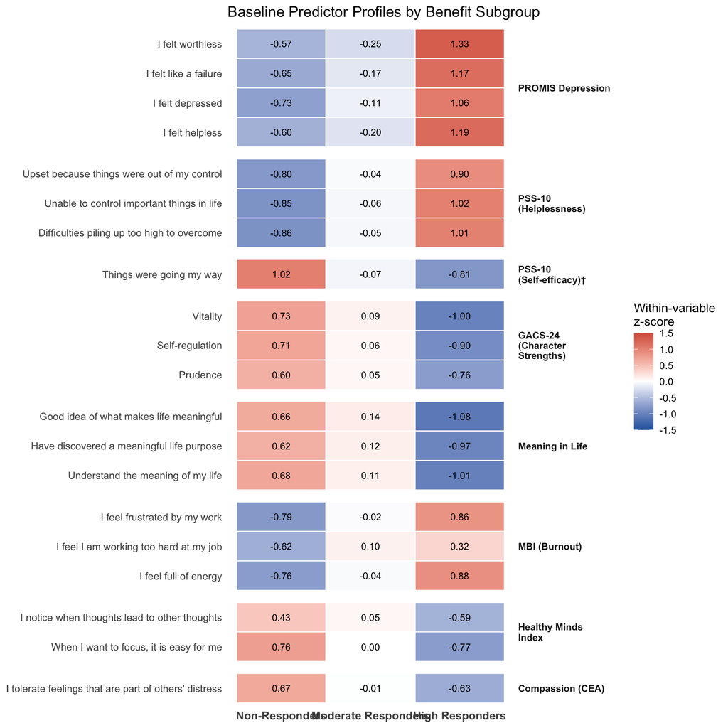

```r
ggplot(heat_data, aes(x = benefit_group, y = item_label, fill = z_mean)) +
  geom_tile(colour = "white", linewidth = 0.4) +
  geom_text(aes(label = sprintf("%.2f", z_mean)), size = 3, colour = "black") +
  scale_fill_gradient2(low = "#2166ac", mid = "white", high = "#d6604d", midpoint = 0,
    limits = c(-1.5, 1.5), oob = scales::squish, name = "Within-variable\nz-score") +
  facet_grid(scale ~ ., scales = "free_y", space = "free_y",
             labeller = labeller(scale = label_wrap_gen(18))) +
  labs(x = NULL, y = NULL, title = "Baseline Predictor Profiles by Benefit Subgroup") +
  theme_minimal(base_size = 11) +
  theme(axis.text.x = element_text(size = 10, face = "bold"),
        axis.text.y = element_text(size = 9),
        strip.text.y = element_text(angle = 0, hjust = 0, size = 8.5, face = "bold"),
        panel.grid = element_blank(), legend.position = "right")
```

## 1.6 Top-20 Evaluation Forest (Re-fit for Subgroup ATE)

```r
Y_raw_20 <- mydata$distress_factor * -1
keep_20  <- !is.na(Y_raw_20) & !is.na(ipw_composite) & ipw_composite > 0

X_20   <- as.matrix(mydata %>% select(all_of(top20_cols)))[keep_20, , drop = FALSE]
Y_20   <- as.numeric(scale(Y_raw_20[keep_20]))
W_20   <- W_all[keep_20]
wt_20  <- as.numeric(ipw_composite[keep_20])
pid_20 <- pid_all[keep_20]

stopifnot(
  nrow(X_20) == results_reduced$top20$N,
  identical(pid_20, results_reduced$top20$tau_df$id)
)

cat(sprintf("[%s] Fitting top-20 eval forest (seed = 1)...\n", format(Sys.time(), "%H:%M:%S")))
```

```
[12:04:57] Fitting top-20 eval forest (seed = 1)...
```

```r
set.seed(1)
eval_forest_top20 <- causal_forest(X_20, Y_20, W_20,
  sample.weights = wt_20, num.trees = 4000, seed = 1, num.threads = 1L)

ate_check <- average_treatment_effect(eval_forest_top20)
cat(sprintf("Re-fit ATE = %.4f vs. cached ATE = %.4f — diff = %.4f\n",
            ate_check["estimate"], results_reduced$top20$ATE,
            abs(ate_check["estimate"] - results_reduced$top20$ATE)))
```

```
Re-fit ATE = 0.3376 vs. cached ATE = 0.3376 — diff = 0.0000
```

```r
stopifnot(abs(ate_check["estimate"] - results_reduced$top20$ATE) < 0.001)
```

## 1.7 Subgroup ATE Test — Top-20 Model

```r
stopifnot(identical(tau_df_20$id, pid_20))

idx_low  <- which(tau_df_20$benefit_group == "Non-Responders")
idx_mod  <- which(tau_df_20$benefit_group == "Moderate Responders")
idx_high <- which(tau_df_20$benefit_group == "High Responders")

ate_low  <- average_treatment_effect(eval_forest_top20, subset = idx_low)
ate_mod  <- average_treatment_effect(eval_forest_top20, subset = idx_mod)
ate_high <- average_treatment_effect(eval_forest_top20, subset = idx_high)

diff_est <- as.numeric(ate_high["estimate"] - ate_low["estimate"])
diff_se  <- sqrt(as.numeric(ate_high["std.err"])^2 + as.numeric(ate_low["std.err"])^2)
diff_z   <- diff_est / diff_se
diff_p   <- 2 * pnorm(-abs(diff_z))

cat(sprintf("Subgroup ATEs (top-20):  Non = %.3f (SE %.3f)  Mod = %.3f (SE %.3f)  High = %.3f (SE %.3f)\n",
            ate_low["estimate"], ate_low["std.err"],
            ate_mod["estimate"], ate_mod["std.err"],
            ate_high["estimate"], ate_high["std.err"]))
```

```
Subgroup ATEs (top-20):  Non = -0.044 (SE 0.084)  Mod = 0.316 (SE 0.058)  High = 0.716 (SE 0.123)
```

```r
cat(sprintf("High vs. Non-responder contrast:  diff = %.3f  (SE = %.3f)  z = %.2f  p = %.4g\n",
            diff_est, diff_se, diff_z, diff_p))
```

```
High vs. Non-responder contrast:  diff = 0.759  (SE = 0.149)  z = 5.09  p = 3.634e-07
```

## 1.8 Severity Benchmark — Heterogeneity Beyond Baseline Distress (Top-20)

```r
# --- Regenerate t1_composite (baseline distress) from the 31 baseline items. ---
# Mirrors efa_change_scores.qmd Part 1 exactly: sorted PROMIS items, then PSS-10
# and WHO-5; unrotated 1-factor ML EFA on the polychoric correlation with
# regression scores; t1 factor score standardized to its own mean/SD.
anx_items_t1  <- sort(names(full_data)[grepl("^t1_promis_edanx", names(full_data))])
dep_items_t1  <- sort(names(full_data)[grepl("^t1_promis_eddep", names(full_data))])
pss_items_t1  <- paste0("t1_pss10_", 1:10)
who5_items_t1 <- paste0("t1_who5_",  1:5)
all_items_t1  <- c(anx_items_t1, dep_items_t1, pss_items_t1, who5_items_t1)

t1_mat_comp        <- as.data.frame(full_data[, all_items_t1])
t1_item_means_comp <- colMeans(t1_mat_comp, na.rm = TRUE)
t1_item_sds_comp   <- apply(t1_mat_comp, 2, sd, na.rm = TRUE)
poly_comp          <- psych::polychoric(t1_mat_comp)
n_obs_comp         <- sum(complete.cases(t1_mat_comp))

efa_comp <- psych::fa(r = poly_comp$rho, nfactors = 1, n.obs = n_obs_comp,
                      rotate = "none", fm = "ml", scores = "regression")

# t1 factor score (regression weights on baseline-standardized items).
t1_std_items <- sweep(sweep(as.matrix(t1_mat_comp), 2, t1_item_means_comp, "-"),
                      2, t1_item_sds_comp, "/")
t1_score <- as.vector(t1_std_items %*% efa_comp$weights)
t1_score[!complete.cases(t1_mat_comp)] <- NA
t1_composite_vec <- (t1_score - mean(t1_score, na.rm = TRUE)) / sd(t1_score, na.rm = TRUE)

sev_efa <- data.frame(id = full_data$id, t1_composite = t1_composite_vec)

sev_df <- tau_df_20 %>%
  left_join(sev_efa %>% select(id, t1_composite), by = "id")
stopifnot(identical(sev_df$id, pid_20))        # row order matches the eval forest

# A few baseline values are missing -> median-impute so the priority vector is complete.
t1c   <- sev_df$t1_composite
t1c[is.na(t1c)] <- median(t1c, na.rm = TRUE)

# Shared AUTOC settings — identical to the primary call in run_hte().
autoc_rule <- function(pri) {
  set.seed(12345)
  ro <- rank_average_treatment_effect(eval_forest_top20, priorities = pri,
          target = "AUTOC", q = seq(0.05, 1, length.out = 100), R = 200)
  c(est = as.numeric(ro$estimate), se = as.numeric(ro$std.err),
    p   = 2 * pnorm(-abs(ro$estimate / ro$std.err)))
}

# Integrity guard: scoring the forest CATE here must reproduce the primary top-20 AUTOC.
a_forest <- autoc_rule(sev_df$tau)
cat(sprintf("Forest-CATE AUTOC (guard) = %.4f  vs. cached %.4f\n",
            a_forest["est"], results_reduced$top20$AUTOC))
```

```
Forest-CATE AUTOC (guard) = 0.2064  vs. cached 0.2064
```

```r
stopifnot(abs(a_forest["est"] - results_reduced$top20$AUTOC) < 0.001)

# Severity-only rule, and the residualized rule (CATE | baseline distress removed).
a_sevonly <- autoc_rule(t1c)
a_resid   <- autoc_rule(residuals(lm(sev_df$tau ~ t1c)))

cat(sprintf("Severity-only AUTOC (baseline distress as priority)   = %.4f  (SE %.4f)  p = %.4g\n",
            a_sevonly["est"], a_sevonly["se"], a_sevonly["p"]))
```

```
Severity-only AUTOC (baseline distress as priority)   = 0.1382  (SE 0.0581)  p = 0.01737
```

```r
cat(sprintf("Residual AUTOC (CATE | baseline distress removed)     = %.4f  (SE %.4f)  p = %.4g\n",
            a_resid["est"], a_resid["se"], a_resid["p"]))
```

```
Residual AUTOC (CATE | baseline distress removed)     = 0.1384  (SE 0.0497)  p = 0.005408
```

# 2 Part B — Component Models (4 Component Outcomes)

## 2.1 Component Full Models

The four component full models (used for the 5-outcome ATE/AUTOC matrix and for the per-component eval forests) are fit via `run_hte()` and held in memory.

```r
component_config <- list(
  list(key = "anxiety",    col = "t8.anx.scale",    label = "PROMIS Anxiety",    direction = "negate"),
  list(key = "depression", col = "t8.dep.scale",    label = "PROMIS Depression", direction = "negate"),
  list(key = "stress",     col = "t8.stress.scale", label = "PSS-10 Stress",     direction = "negate"),
  list(key = "wellbeing",  col = "t8_wellbeing",    label = "WHO-5 Wellbeing",   direction = "keep")
)
```

```r
# Full component models held in memory (comp_full); consumed by the VI-extraction
# loop and the 5-outcome summary below.
comp_full <- list()
for (cfg in component_config) {
  cat(sprintf("[%s] Fitting component full model: %s\n", format(Sys.time(), "%H:%M:%S"), cfg$label))
  comp_full[[cfg$key]] <- run_hte(
    outcome_col = cfg$col, label = cfg$label, direction = cfg$direction,
    ipw_vec = ipw_weights[[cfg$key]], mydata = mydata,
    X_mat = X_all, W_all = W_all, pid_all = pid_all,
    p_cols = pred_cols, grp_map = group_map
  )
}
```

```
[12:05:08] Fitting component full model: PROMIS Anxiety

--- PROMIS Anxiety
    N = 1463  (W=1: 695, W=0: 768)  predictors = 184
    ATE: 0.2495  (SE = 0.0475)
    AUTOC: -0.0154  SE: 0.0475  95% CI [-0.1086, 0.0778]  p = 0.7460
[12:07:33] Fitting component full model: PROMIS Depression

--- PROMIS Depression
    N = 1462  (W=1: 694, W=0: 768)  predictors = 184
    ATE: 0.3328  (SE = 0.0488)
    AUTOC: -0.0069  SE: 0.0541  95% CI [-0.1130, 0.0991]  p = 0.8979
[12:09:57] Fitting component full model: PSS-10 Stress

--- PSS-10 Stress
    N = 1460  (W=1: 693, W=0: 767)  predictors = 184
    ATE: 0.3272  (SE = 0.0457)
    AUTOC: 0.1304  SE: 0.0467  95% CI [0.0389, 0.2219]  p = 0.0052
[12:12:18] Fitting component full model: WHO-5 Wellbeing

--- WHO-5 Wellbeing
    N = 1465  (W=1: 697, W=0: 768)  predictors = 184
    ATE: 0.4579  (SE = 0.0483)
    AUTOC: 0.1369  SE: 0.0548  95% CI [0.0295, 0.2443]  p = 0.0125
```

## 2.2 Step 1: Extract Individual VI From Each Component Full Model

Eval-only refit (deterministic given `set.seed(1) + seed = 1`) to extract individual VI for top-N selection and to save the per-component eval forest for subgroup ATEs. Validates the eval-only ATE against the cached main-analysis ATE.

```r
extract_eval_vi <- function(outcome_col, label, direction,
                             ipw_vec, mydata, X_mat, W_all, pid_all,
                             p_cols, grp_map, n_trees = 4000) {
  Y_raw <- mydata[[outcome_col]]
  if (direction == "negate") Y_raw <- Y_raw * -1

  keep <- !is.na(Y_raw) & !is.na(ipw_vec) & ipw_vec > 0
  X   <- X_mat[keep, , drop = FALSE]
  Y   <- as.numeric(scale(Y_raw[keep]))
  W   <- W_all[keep]
  wt  <- as.numeric(ipw_vec[keep])
  pid <- pid_all[keep]
  N   <- sum(keep)

  cat(sprintf("    N = %d  (W=1: %d, W=0: %d)  predictors = %d\n",
              N, sum(W == 1), sum(W == 0), ncol(X)))

  set.seed(1)
  eval_forest <- causal_forest(X, Y, W, sample.weights = wt, num.trees = n_trees, seed = 1, num.threads = 1L)

  ate_obj <- average_treatment_effect(eval_forest)
  ATE     <- as.numeric(ate_obj["estimate"]); ATE_SE <- as.numeric(ate_obj["std.err"])

  vi_raw <- variable_importance(eval_forest)
  vi_df  <- data.frame(variable = p_cols, importance = as.numeric(vi_raw)) %>%
    left_join(grp_map %>% select(variable, group), by = "variable") %>%
    mutate(group = tidyr::replace_na(group, "Other / unmapped")) %>%
    arrange(desc(importance))

  list(label = label, outcome_col = outcome_col,
       N = N, N_treated = sum(W == 1), N_control = sum(W == 0),
       ATE = ATE, ATE_SE = ATE_SE, vi_df = vi_df, eval_forest = eval_forest, pid = pid)
}
```

```r
vi_results        <- list()
full_cached       <- list()
comp_eval_forests <- list()   # in-memory per-component eval forests (for subgroup ATEs)

for (cfg in component_config) {
  key <- cfg$key
  cat(sprintf("\n----- %s -----\n", cfg$label))

  full_cached[[key]] <- comp_full[[key]]   # in-memory full main-analysis model

  cat(sprintf("[%s] Fitting eval forest (seed=1) to extract VI...\n", format(Sys.time(), "%H:%M:%S")))
  tmp <- extract_eval_vi(
    outcome_col = cfg$col, label = cfg$label, direction = cfg$direction,
    ipw_vec = ipw_weights[[key]], mydata = mydata, X_mat = X_all,
    W_all = W_all, pid_all = pid_all, p_cols = pred_cols, grp_map = group_map
  )
  vi_results[[key]]        <- tmp[setdiff(names(tmp), c("eval_forest", "pid"))]
  comp_eval_forests[[key]] <- list(forest = tmp$eval_forest, pid = tmp$pid)

  r_new <- vi_results[[key]]; r_old <- full_cached[[key]]; tol <- 1e-4
  ate_diff <- abs(r_new$ATE - r_old$ATE); ate_se_diff <- abs(r_new$ATE_SE - r_old$ATE_SE)
  n_diff <- r_new$N - r_old$N

  if (ate_diff > tol || ate_se_diff > tol || n_diff != 0) {
    cat(sprintf("  WARNING: ATE / N mismatch vs cached main-analysis result\n"))
    stop(sprintf("ATE reproducibility check failed for '%s'.", key))
  } else {
    cat(sprintf("  PASS  ATE = %.4f (SE = %.4f)  matches cached main-analysis.\n",
                r_new$ATE, r_new$ATE_SE))
  }
}
```

```
----- PROMIS Anxiety -----
[12:14:44] Fitting eval forest (seed=1) to extract VI...
    N = 1463  (W=1: 695, W=0: 768)  predictors = 184
  PASS  ATE = 0.2495 (SE = 0.0475)  matches cached main-analysis.

----- PROMIS Depression -----
[12:14:59] Fitting eval forest (seed=1) to extract VI...
    N = 1462  (W=1: 694, W=0: 768)  predictors = 184
  PASS  ATE = 0.3328 (SE = 0.0488)  matches cached main-analysis.

----- PSS-10 Stress -----
[12:15:13] Fitting eval forest (seed=1) to extract VI...
    N = 1460  (W=1: 693, W=0: 767)  predictors = 184
  PASS  ATE = 0.3272 (SE = 0.0457)  matches cached main-analysis.

----- WHO-5 Wellbeing -----
[12:15:28] Fitting eval forest (seed=1) to extract VI...
    N = 1465  (W=1: 697, W=0: 768)  predictors = 184
  PASS  ATE = 0.4579 (SE = 0.0483)  matches cached main-analysis.
```

```r
cat("\nAll VI extractions complete and validated.\n")
```

```
All VI extractions complete and validated.
```

## 2.3 Step 2: Fit Top 10 / 20 / 30 Reduced Models for Each Component

```r
all_results_comp <- list()

for (cfg in component_config) {
  key <- cfg$key
  cat(sprintf("\n==========  %s  ==========\n", cfg$label))

  vi_all_c   <- vi_results[[key]]$vi_df
  reduced_configs_c <- list(
    list(n = 10, cols = vi_all_c$variable[1:10]),
    list(n = 20, cols = vi_all_c$variable[1:20]),
    list(n = 30, cols = vi_all_c$variable[1:30])
  )

  results_reduced_c <- list()

  for (rc in reduced_configs_c) {
    key_r   <- sprintf("top%d", rc$n)
    label_r <- sprintf("%s — Top %d Predictors", cfg$label, rc$n)

    cat(sprintf("[%s] Fitting: %s\n", format(Sys.time(), "%H:%M:%S"), label_r))
    X_sub   <- as.matrix(mydata %>% select(all_of(rc$cols)))
    grp_sub <- group_map %>% filter(variable %in% rc$cols)
    results_reduced_c[[key_r]] <- run_hte(
      outcome_col = cfg$col, label = label_r, direction = cfg$direction,
      ipw_vec = ipw_weights[[key]], mydata = mydata,
      X_mat = X_sub, W_all = W_all, pid_all = pid_all,
      p_cols = rc$cols, grp_map = grp_sub
    )
  }

  all_results_comp[[key]] <- list(
    full  = full_cached[[key]],
    top10 = results_reduced_c$top10,
    top20 = results_reduced_c$top20,
    top30 = results_reduced_c$top30
  )
}
```

```
==========  PROMIS Anxiety  ==========
[12:15:43] Fitting: PROMIS Anxiety — Top 10 Predictors

--- PROMIS Anxiety — Top 10 Predictors
    N = 1463  (W=1: 695, W=0: 768)  predictors = 10
    ATE: 0.2474  (SE = 0.0490)
    AUTOC: 0.0964  SE: 0.0439  95% CI [0.0103, 0.1825]  p = 0.0281
[12:16:37] Fitting: PROMIS Anxiety — Top 20 Predictors

--- PROMIS Anxiety — Top 20 Predictors
    N = 1463  (W=1: 695, W=0: 768)  predictors = 20
    ATE: 0.2424  (SE = 0.0488)
    AUTOC: 0.0523  SE: 0.0472  95% CI [-0.0401, 0.1448]  p = 0.2673
[12:18:12] Fitting: PROMIS Anxiety — Top 30 Predictors

--- PROMIS Anxiety — Top 30 Predictors
    N = 1463  (W=1: 695, W=0: 768)  predictors = 30
    ATE: 0.2428  (SE = 0.0484)
    AUTOC: 0.0389  SE: 0.0483  95% CI [-0.0557, 0.1334]  p = 0.4206

==========  PROMIS Depression  ==========
[12:20:16] Fitting: PROMIS Depression — Top 10 Predictors

--- PROMIS Depression — Top 10 Predictors
    N = 1462  (W=1: 694, W=0: 768)  predictors = 10
    ATE: 0.3164  (SE = 0.0499)
    AUTOC: 0.0712  SE: 0.0504  95% CI [-0.0276, 0.1701]  p = 0.1577
[12:21:07] Fitting: PROMIS Depression — Top 20 Predictors

--- PROMIS Depression — Top 20 Predictors
    N = 1462  (W=1: 694, W=0: 768)  predictors = 20
    ATE: 0.3324  (SE = 0.0489)
    AUTOC: 0.0514  SE: 0.0496  95% CI [-0.0459, 0.1486]  p = 0.3005
[12:22:36] Fitting: PROMIS Depression — Top 30 Predictors

--- PROMIS Depression — Top 30 Predictors
    N = 1462  (W=1: 694, W=0: 768)  predictors = 30
    ATE: 0.3298  (SE = 0.0489)
    AUTOC: 0.0604  SE: 0.0505  95% CI [-0.0386, 0.1594]  p = 0.2317

```

[output cut: 24 more lines]

```
    N = 1465  (W=1: 697, W=0: 768)  predictors = 10
    ATE: 0.4654  (SE = 0.0500)
    AUTOC: 0.1897  SE: 0.0546  95% CI [0.0826, 0.2967]  p = 0.0005
[12:29:39] Fitting: WHO-5 Wellbeing — Top 20 Predictors

--- WHO-5 Wellbeing — Top 20 Predictors
    N = 1465  (W=1: 697, W=0: 768)  predictors = 20
    ATE: 0.4709  (SE = 0.0492)
    AUTOC: 0.1851  SE: 0.0532  95% CI [0.0808, 0.2894]  p = 0.0005
[12:31:08] Fitting: WHO-5 Wellbeing — Top 30 Predictors

--- WHO-5 Wellbeing — Top 30 Predictors
    N = 1465  (W=1: 697, W=0: 768)  predictors = 30
    ATE: 0.4630  (SE = 0.0489)
    AUTOC: 0.2064  SE: 0.0539  95% CI [0.1009, 0.3120]  p = 0.0001
```

```r
cat("\nAll component reduced models complete.\n")
```

```
All component reduced models complete.
```

## 2.4 Combined 5-Outcome Summary (Composite + Components)

```r
sig_mark <- function(p) dplyr::case_when(p < .001 ~ "***", p < .01 ~ "**", p < .05 ~ "*", TRUE ~ "")

canonical_label <- setNames(
  sapply(component_config, function(x) x$label),
  sapply(component_config, function(x) x$key)
)
n_pred_full <- length(pred_cols)

# Long-form component rows
rows <- list()
for (key in names(all_results_comp)) {
  for (sub in c("full", "top10", "top20", "top30")) {
    r      <- all_results_comp[[key]][[sub]]
    n_pred <- if (sub == "full") n_pred_full else r$n_predictors
    rows[[length(rows) + 1]] <- tibble(
      outcome = canonical_label[[key]], key = key, config = sub,
      N = r$N, n_pred = n_pred,
      ATE = r$ATE, ATE_SE = r$ATE_SE, AUTOC = r$AUTOC, AUTOC_SE = r$AUTOC_SE, p = r$p
    )
  }
}
long_df <- bind_rows(rows)

# Composite rows (in-memory objects from Part A)
comp_rows <- list(
  list(r = res_full,                sub = "full"),
  list(r = results_reduced$top10,   sub = "top10"),
  list(r = results_reduced$top20,   sub = "top20"),
  list(r = results_reduced$top30,   sub = "top30")
)
comp_df <- bind_rows(lapply(comp_rows, function(x) {
  tibble(outcome = "Distress Composite", key = "composite", config = x$sub,
         N = x$r$N, n_pred = x$r$n_predictors,
         ATE = x$r$ATE, ATE_SE = x$r$ATE_SE,
         AUTOC = x$r$AUTOC, AUTOC_SE = x$r$AUTOC_SE, p = x$r$p)
}))

combined_df <- bind_rows(comp_df, long_df %>% select(names(comp_df))) %>%
  mutate(outcome = factor(outcome,
    levels = c("Distress Composite", "WHO-5 Wellbeing", "PROMIS Anxiety",
               "PROMIS Depression", "PSS-10 Stress"))) %>%
  arrange(outcome, match(config, c("full", "top10", "top20", "top30")))

# Benjamini-Hochberg FDR within each outcome across the three reduced specs
# (Top 10/20/30, one family per outcome). The Full (184-predictor) model is the
# no-selection baseline and keeps its raw p. p_star drives the significance stars
# in the AUTOC table (Table 3): raw p for Full, FDR-adjusted p for the reduced specs.
bh_reduced <- function(p, config) {
  out <- p                                    # Full keeps its raw p
  red <- config != "full"
  out[red] <- p.adjust(p[red], method = "BH")
  out
}
combined_df <- combined_df %>%
  group_by(outcome) %>%
  mutate(p_star = bh_reduced(p, config),
         p_BH   = ifelse(config == "full", NA_real_, p_star)) %>%
  ungroup()

# ATE matrix (outcome × config)
ate_mat <- combined_df %>%
  mutate(config = factor(config, levels = c("full", "top10", "top20", "top30"),
                         labels = c("Full", "Top 10", "Top 20", "Top 30")),
         ate_str = sprintf("%.3f (%.3f)%s", ATE, ATE_SE,
                           sig_mark(2 * pnorm(-abs(ATE / ATE_SE))))) %>%
  select(Outcome = outcome, N, config, ate_str) %>%
  pivot_wider(names_from = config, values_from = ate_str)

# AUTOC matrix (outcome × config). Each predictor specification is emitted as a PAIR of
# columns — the AU-TOC estimate (carrying the significance stars) and a separate SE column
# (bare number, no parentheses) — per Ron's "Est (SE) pairs" request. Stars use p_star: raw p
# for Full, FDR-adjusted p (BH within outcome across the three reduced specs) for Top 10/20/30.
# See note in the manuscript Table 2 caption.
autoc_mat <- combined_df %>%
  mutate(config = factor(config, levels = c("full", "top10", "top20", "top30"),
                         labels = c("Full", "Top 10", "Top 20", "Top 30")),
         est = sprintf("%.3f%s", AUTOC, sig_mark(p_star)),
         se  = sprintf("%.3f", AUTOC_SE)) %>%
  select(Outcome = outcome, N, config, est, se) %>%
  pivot_wider(names_from = config, values_from = c(est, se),
              names_glue = "{config}__{.value}") %>%
  select(Outcome, N,
         `Full`         = `Full__est`,    `Full SE`   = `Full__se`,
         `Top 10`       = `Top 10__est`,  `Top 10 SE` = `Top 10__se`,
         `Top 20`       = `Top 20__est`,  `Top 20 SE` = `Top 20__se`,
         `Top 30`       = `Top 30__est`,  `Top 30 SE` = `Top 30__se`)

knitr::kable(ate_mat,   caption = "Table 2 — ATE (SE) across 5 outcomes × predictor subsets.")
```

Table 2 — ATE (SE) across 5 outcomes × predictor subsets.

| Outcome | N | Full | Top 10 | Top 20 | Top 30 |
| --- | --- | --- | --- | --- | --- |
| Distress Composite | 1435 | 0.329 (0.047)*** | 0.319 (0.048)*** | 0.338 (0.047)*** | 0.337 (0.047)*** |
| WHO-5 Wellbeing | 1465 | 0.458 (0.048)*** | 0.465 (0.050)*** | 0.471 (0.049)*** | 0.463 (0.049)*** |
| PROMIS Anxiety | 1463 | 0.250 (0.047)*** | 0.247 (0.049)*** | 0.242 (0.049)*** | 0.243 (0.048)*** |
| PROMIS Depression | 1462 | 0.333 (0.049)*** | 0.316 (0.050)*** | 0.332 (0.049)*** | 0.330 (0.049)*** |
| PSS-10 Stress | 1460 | 0.327 (0.046)*** | 0.326 (0.047)*** | 0.317 (0.047)*** | 0.315 (0.046)*** |

```r
knitr::kable(autoc_mat, caption = "Table 3 — AUTOC (SE) across 5 outcomes × predictor subsets.")
```

Table 3 — AUTOC (SE) across 5 outcomes × predictor subsets.

| Outcome | N | Full | Full SE | Top 10 | Top 10 SE | Top 20 | Top 20 SE | Top 30 | Top 30 SE |
| --- | --- | --- | --- | --- | --- | --- | --- | --- | --- |
| Distress Composite | 1435 | 0.155* | 0.061 | 0.202*** | 0.051 | 0.206*** | 0.051 | 0.194*** | 0.052 |
| WHO-5 Wellbeing | 1465 | 0.137* | 0.055 | 0.190*** | 0.055 | 0.185*** | 0.053 | 0.206*** | 0.054 |
| PROMIS Anxiety | 1463 | -0.015 | 0.048 | 0.096 | 0.044 | 0.052 | 0.047 | 0.039 | 0.048 |
| PROMIS Depression | 1462 | -0.007 | 0.054 | 0.071 | 0.050 | 0.051 | 0.050 | 0.060 | 0.050 |
| PSS-10 Stress | 1460 | 0.130** | 0.047 | 0.135** | 0.047 | 0.136** | 0.045 | 0.141** | 0.047 |

## 2.5 AUTOC FDR Correction Across Reduced Specs (Exploratory)

```r
fdr_df <- combined_df %>%
  filter(config %in% c("top10", "top20", "top30")) %>%
  mutate(config  = factor(config, levels = c("top10", "top20", "top30"),
                          labels = c("Top 10", "Top 20", "Top 30")),
         sig_raw = sig_mark(p),
         sig_BH  = sig_mark(p_BH)) %>%
  arrange(outcome, config) %>%
  select(Outcome = outcome, Spec = config, AUTOC, AUTOC_SE,
         p_raw = p, sig_raw, p_BH, sig_BH)

knitr::kable(fdr_df, digits = 4,
  caption = "AUTOC with Benjamini-Hochberg FDR correction across the three reduced specs (Top 10/20/30), applied separately within each outcome.")
```

AUTOC with Benjamini-Hochberg FDR correction across the three reduced specs (Top 10/20/30), applied separately within each outcome.

| Outcome | Spec | AUTOC | AUTOC_SE | p_raw | sig_raw | p_BH | sig_BH |
| --- | --- | --- | --- | --- | --- | --- | --- |
| Distress Composite | Top 10 | 0.2020 | 0.0513 | 0.0001 | *** | 0.0001 | *** |
| Distress Composite | Top 20 | 0.2064 | 0.0508 | 0.0000 | *** | 0.0001 | *** |
| Distress Composite | Top 30 | 0.1937 | 0.0518 | 0.0002 | *** | 0.0002 | *** |
| WHO-5 Wellbeing | Top 10 | 0.1897 | 0.0546 | 0.0005 | *** | 0.0005 | *** |
| WHO-5 Wellbeing | Top 20 | 0.1851 | 0.0532 | 0.0005 | *** | 0.0005 | *** |
| WHO-5 Wellbeing | Top 30 | 0.2064 | 0.0539 | 0.0001 | *** | 0.0004 | *** |
| PROMIS Anxiety | Top 10 | 0.0964 | 0.0439 | 0.0281 | * | 0.0844 |  |
| PROMIS Anxiety | Top 20 | 0.0523 | 0.0472 | 0.2673 |  | 0.4009 |  |
| PROMIS Anxiety | Top 30 | 0.0389 | 0.0483 | 0.4206 |  | 0.4206 |  |
| PROMIS Depression | Top 10 | 0.0712 | 0.0504 | 0.1577 |  | 0.3005 |  |
| PROMIS Depression | Top 20 | 0.0514 | 0.0496 | 0.3005 |  | 0.3005 |  |
| PROMIS Depression | Top 30 | 0.0604 | 0.0505 | 0.2317 |  | 0.3005 |  |
| PSS-10 Stress | Top 10 | 0.1349 | 0.0466 | 0.0038 | ** | 0.0038 | ** |
| PSS-10 Stress | Top 20 | 0.1356 | 0.0449 | 0.0025 | ** | 0.0038 | ** |
| PSS-10 Stress | Top 30 | 0.1415 | 0.0467 | 0.0025 | ** | 0.0038 | ** |

## 2.6 Variable Importance Distribution Figure (eFigure)

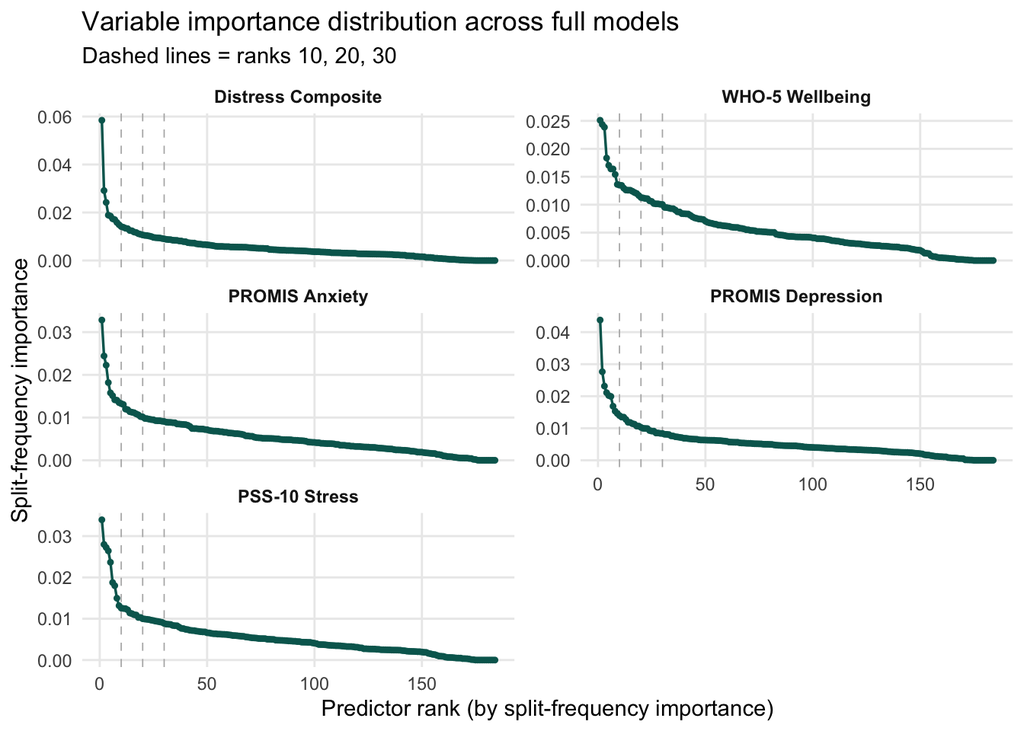

```r
vi_panels <- list(
  tibble(outcome = "Distress Composite", vi = res_full$vi_df$importance),
  tibble(outcome = "WHO-5 Wellbeing",   vi = vi_results$wellbeing$vi_df$importance),
  tibble(outcome = "PROMIS Anxiety",    vi = vi_results$anxiety$vi_df$importance),
  tibble(outcome = "PROMIS Depression", vi = vi_results$depression$vi_df$importance),
  tibble(outcome = "PSS-10 Stress",     vi = vi_results$stress$vi_df$importance)
)

vi_scree_df <- bind_rows(lapply(vi_panels, function(d) {
  d %>% arrange(desc(vi)) %>% mutate(rank = row_number())
})) %>%
  mutate(outcome = factor(outcome,
    levels = c("Distress Composite", "WHO-5 Wellbeing", "PROMIS Anxiety",
               "PROMIS Depression", "PSS-10 Stress")))

p_vi_scree <- ggplot(vi_scree_df, aes(x = rank, y = vi)) +
  geom_vline(xintercept = c(10, 20, 30), colour = "grey70", linetype = "dashed", linewidth = 0.3) +
  geom_line(colour = "#01665e", linewidth = 0.6) +
  geom_point(colour = "#01665e", size = 0.9) +
  facet_wrap(~ outcome, ncol = 2, scales = "free_y") +
  labs(x = "Predictor rank (by split-frequency importance)",
       y = "Split-frequency importance",
       title = "Variable importance distribution across full models",
       subtitle = "Dashed lines = ranks 10, 20, 30") +
  theme_minimal(base_size = 11) +
  theme(panel.grid.minor = element_blank(), strip.text = element_text(face = "bold"))

print(p_vi_scree)
```

# 3 Part C — Engagement Analyses

## 3.1 Load engagement data

```r
# Engagement metrics (week-13 sessions attended and app minutes) are PRE-MERGED
# into the de-identified file. They live on `full_data` (the untouched copy taken
# at read-in); `mydata` was rebuilt into the predictor matrix above and no longer
# carries them. Arm is joined from `mydata` so the coding is identical to the one
# the forests used. The public file carries no exp_group column, so the treatment
# arm is taken from `intervention_group` (control = 0; engagement is
# structurally zero in control).
df_eng <- full_data %>%
  dplyr::select(id, week_13_total_attendance, week_13_app_minutes) %>%
  dplyr::left_join(mydata %>% dplyr::select(id, intervention_group), by = "id") %>%
  dplyr::select(id, intervention_group, week_13_total_attendance, week_13_app_minutes)

stopifnot(nrow(df_eng) == nrow(mydata), !any(is.na(df_eng$intervention_group)))
df_eng$total_session_engagement <- df_eng$week_13_total_attendance
df_eng$total_app_minutes        <- df_eng$week_13_app_minutes

cat("df_eng rows:", nrow(df_eng), "\n")
```

```
df_eng rows: 2315
```

```r
cat("Intervention-arm rows (intervention_group == 1):",
    sum(df_eng$intervention_group == 1), "\n")
```

```
Intervention-arm rows (intervention_group == 1): 1157
```

## 3.2 Full-sample CATE assignment (extend top-20 CATEs to non-completers)

Re-fits the 10 top-20 fold causal forests with identical seeds (sanity-checked to reproduce the cached OOF CATEs exactly), then assigns each non-completer a CATE = mean of the 10 held-out fold forests, so engagement can be compared across the full intervention arm.

```r
Y_raw_t20 <- mydata$distress_factor * -1
keep_t20  <- !is.na(Y_raw_t20) & !is.na(ipw_composite) & ipw_composite > 0

X_t20   <- as.matrix(mydata %>% select(all_of(top20_cols)))[keep_t20, , drop = FALSE]
Y_t20   <- as.numeric(scale(Y_raw_t20[keep_t20]))
W_t20   <- W_all[keep_t20]
wt_t20  <- as.numeric(ipw_composite[keep_t20])
pid_t20 <- pid_all[keep_t20]
N_t20   <- sum(keep_t20)

stopifnot(N_t20 == results_reduced$top20$N,
          identical(pid_t20, results_reduced$top20$tau_df$id))

K <- 10
foldID_t20 <- integer(N_t20)
set.seed(12345)
for (g in 0:1) {
  idx <- which(W_t20 == g)
  foldID_t20[idx] <- sample(rep(1:K, length.out = length(idx)))
}

cat(sprintf("[%s] Fitting 10 top-20 fold forests...\n", format(Sys.time(), "%H:%M:%S")))
```

```
[12:33:06] Fitting 10 top-20 fold forests...
```

```r
fold_forests_t20 <- vector("list", K)
for (fold in 1:K) {
  train <- which(foldID_t20 != fold)
  set.seed(123456 + fold)
  fold_forests_t20[[fold]] <- causal_forest(
    X_t20[train, , drop = FALSE], Y_t20[train], W_t20[train],
    sample.weights = wt_t20[train], num.trees = 4000, seed = 123456 + fold, num.threads = 1L)
  cat(sprintf("  fold %2d/%d done\n", fold, K))
}
```

```
  fold  1/10 done
  fold  2/10 done
  fold  3/10 done
  fold  4/10 done
  fold  5/10 done
  fold  6/10 done
  fold  7/10 done
  fold  8/10 done
  fold  9/10 done
  fold 10/10 done
```

```r
tau_oof_refit <- rep(NA_real_, N_t20)
for (fold in 1:K) {
  test <- which(foldID_t20 == fold)
  tau_oof_refit[test] <- as.numeric(predict(fold_forests_t20[[fold]],
                                            X_t20[test, , drop = FALSE])$predictions)
}
stopifnot(sum(is.na(tau_oof_refit)) == 0)
diff_max <- max(abs(tau_oof_refit - results_reduced$top20$tau_df$tau))
cat(sprintf("Refit vs. cached OOF tau:  max |diff| = %.2e\n", diff_max))
```

```
Refit vs. cached OOF tau:  max |diff| = 0.00e+00
```

```r
stopifnot(diff_max < 1e-10)
cat("Sanity check passed — fold forests reproduce cached OOF CATEs exactly.\n")
```

```
Sanity check passed — fold forests reproduce cached OOF CATEs exactly.
```

```r
nc_idx <- which(!keep_t20)
N_nc   <- length(nc_idx)
X_nc   <- as.matrix(mydata[nc_idx, top20_cols, drop = FALSE])
pid_nc <- pid_all[nc_idx]
stopifnot(sum(is.na(X_nc)) == 0)

nc_preds <- matrix(NA_real_, nrow = N_nc, ncol = K)
for (fold in 1:K) {
  nc_preds[, fold] <- as.numeric(predict(fold_forests_t20[[fold]], X_nc)$predictions)
}
tau_nc <- rowMeans(nc_preds)
cat(sprintf("Non-completer N: %d  (completer N: %d  ;  total: %d)\n", N_nc, N_t20, N_nc + N_t20))
```

```
Non-completer N: 880  (completer N: 1435  ;  total: 2315)
```

```r
tau_df_full <- bind_rows(
  results_reduced$top20$tau_df %>% mutate(completer = TRUE,  source = "OOF (held-out fold)"),
  tibble(id = pid_nc, tau = tau_nc) %>% mutate(completer = FALSE, source = "Mean of 10 fold forests")
)
stopifnot(nrow(tau_df_full) == nrow(mydata), !any(duplicated(tau_df_full$id)))

tau_df_full <- tau_df_full %>%
  mutate(
    benefit_group = case_when(
      tau <  q20_cut ~ "Non-Responders",
      tau >= q80_cut ~ "High Responders",
      TRUE           ~ "Moderate Responders"
    ),
    benefit_group = factor(benefit_group,
      levels = c("Non-Responders", "Moderate Responders", "High Responders"), ordered = TRUE)
  )
cat(sprintf("tau_df_full assembled:  N = %d  (completers = %d, non-completers = %d)\n",
            nrow(tau_df_full), sum(tau_df_full$completer), sum(!tau_df_full$completer)))
```

```
tau_df_full assembled:  N = 2315  (completers = 1435, non-completers = 880)
```

## 3.3 Engagement by benefit subgroup (full intervention arm)

```r
int_eng <- df_eng[df_eng$intervention_group == 1, , drop = FALSE]
int_eng$id_chr <- as.character(int_eng$id)

sub_full_df <- tau_df_full %>%
  mutate(id_chr = as.character(id)) %>%
  select(id_chr, benefit_group, completer, tau)

ipw_df <- tibble(id_chr = as.character(mydata$id), ipw = ipw_composite)

merged_full <- int_eng %>%
  inner_join(sub_full_df, by = "id_chr") %>%
  left_join(ipw_df, by = "id_chr")

merged_full$benefit_group <- factor(merged_full$benefit_group,
  levels = c("Non-Responders", "Moderate Responders", "High Responders"))

cat(sprintf("Intervention participants matched to a subgroup: %d (completers = %d, non-completers = %d)\n",
            nrow(merged_full), sum(merged_full$completer), sum(!merged_full$completer)))
```

```
Intervention participants matched to a subgroup: 1157 (completers = 680, non-completers = 477)
```

## 3.4 Predicted-engagement interaction (does engageability moderate the ITT effect?)

Two 10-fold cross-validated regression forests predict each participant’s engagement from the full baseline predictor set; predicted engagement is then tested as a moderator in an IPW-weighted linear model with HC3 robust SEs.

```r
eng_for_merge <- df_eng %>%
  mutate(id_chr = as.character(id)) %>%
  select(id_chr, total_session_engagement, total_app_minutes)
mydata_id_chr <- as.character(mydata$id)
eng_lookup <- eng_for_merge[match(mydata_id_chr, eng_for_merge$id_chr), , drop = FALSE]
stopifnot(identical(eng_lookup$id_chr, mydata_id_chr))

eng_sess_all <- eng_lookup$total_session_engagement
eng_app_all  <- eng_lookup$total_app_minutes
```

```r
train_mask_sess <- (W_all == 1) & !is.na(eng_sess_all)
train_mask_app  <- (W_all == 1) & !is.na(eng_app_all)
N_train_sess <- sum(train_mask_sess)
N_train_app  <- sum(train_mask_app)
cat(sprintf("Training N — sessions RF: %d  |  app-min RF: %d\n", N_train_sess, N_train_app))
```

```
Training N — sessions RF: 1156  |  app-min RF: 1156
```

```r
X_tr_sess <- X_all[train_mask_sess, , drop = FALSE]
Y_tr_sess <- as.numeric(eng_sess_all[train_mask_sess])
K <- 10
set.seed(12346)
foldID_sess <- sample(rep(1:K, length.out = N_train_sess))

cat(sprintf("[%s] Fitting 10 sessions-RF fold forests...\n", format(Sys.time(), "%H:%M:%S")))
```

```
[12:34:21] Fitting 10 sessions-RF fold forests...
```

```r
fold_forests_sess <- vector("list", K)
for (fold in 1:K) {
  train <- which(foldID_sess != fold)
  set.seed(234567 + fold)
  fold_forests_sess[[fold]] <- regression_forest(
    X_tr_sess[train, , drop = FALSE], Y_tr_sess[train], num.trees = 4000, seed = 234567 + fold, num.threads = 1L)
  cat(sprintf("  sessions fold %2d/%d done\n", fold, K))
}
```

```
  sessions fold  1/10 done
  sessions fold  2/10 done
  sessions fold  3/10 done
  sessions fold  4/10 done
  sessions fold  5/10 done
  sessions fold  6/10 done
  sessions fold  7/10 done
  sessions fold  8/10 done
  sessions fold  9/10 done
  sessions fold 10/10 done
```

```r
pred_sess <- rep(NA_real_, nrow(mydata))
for (fold in 1:K) {
  test_in_train <- which(foldID_sess == fold)
  train_rows    <- which(train_mask_sess)[test_in_train]
  pred_sess[train_rows] <- as.numeric(predict(fold_forests_sess[[fold]],
                                              X_all[train_rows, , drop = FALSE])$predictions)
}
nontr_rows <- which(!train_mask_sess)
if (length(nontr_rows) > 0) {
  nt_mat <- matrix(NA_real_, nrow = length(nontr_rows), ncol = K)
  for (fold in 1:K) {
    nt_mat[, fold] <- as.numeric(predict(fold_forests_sess[[fold]],
                                         X_all[nontr_rows, , drop = FALSE])$predictions)
  }
  pred_sess[nontr_rows] <- rowMeans(nt_mat)
}
stopifnot(sum(is.na(pred_sess)) == 0)
r2_sess <- 1 - sum((Y_tr_sess - pred_sess[train_mask_sess])^2) / sum((Y_tr_sess - mean(Y_tr_sess))^2)
cat(sprintf("Sessions RF — CV R^2 (n = %d): %.3f\n", N_train_sess, r2_sess))
```

```
Sessions RF — CV R^2 (n = 1156): 0.104
```

```r
X_tr_app <- X_all[train_mask_app, , drop = FALSE]
Y_tr_app <- as.numeric(eng_app_all[train_mask_app])
set.seed(12347)
foldID_app <- sample(rep(1:K, length.out = N_train_app))

cat(sprintf("[%s] Fitting 10 app-min RF fold forests...\n", format(Sys.time(), "%H:%M:%S")))
```

```
[12:35:37] Fitting 10 app-min RF fold forests...
```

```r
fold_forests_app <- vector("list", K)
for (fold in 1:K) {
  train <- which(foldID_app != fold)
  set.seed(345678 + fold)
  fold_forests_app[[fold]] <- regression_forest(
    X_tr_app[train, , drop = FALSE], Y_tr_app[train], num.trees = 4000, seed = 345678 + fold, num.threads = 1L)
  cat(sprintf("  app-min  fold %2d/%d done\n", fold, K))
}
```

```
  app-min  fold  1/10 done
  app-min  fold  2/10 done
  app-min  fold  3/10 done
  app-min  fold  4/10 done
  app-min  fold  5/10 done
  app-min  fold  6/10 done
  app-min  fold  7/10 done
  app-min  fold  8/10 done
  app-min  fold  9/10 done
  app-min  fold 10/10 done
```

```r
pred_app <- rep(NA_real_, nrow(mydata))
for (fold in 1:K) {
  test_in_train <- which(foldID_app == fold)
  train_rows    <- which(train_mask_app)[test_in_train]
  pred_app[train_rows] <- as.numeric(predict(fold_forests_app[[fold]],
                                             X_all[train_rows, , drop = FALSE])$predictions)
}
nontr_rows <- which(!train_mask_app)
if (length(nontr_rows) > 0) {
  nt_mat <- matrix(NA_real_, nrow = length(nontr_rows), ncol = K)
  for (fold in 1:K) {
    nt_mat[, fold] <- as.numeric(predict(fold_forests_app[[fold]],
                                         X_all[nontr_rows, , drop = FALSE])$predictions)
  }
  pred_app[nontr_rows] <- rowMeans(nt_mat)
}
stopifnot(sum(is.na(pred_app)) == 0)
r2_app <- 1 - sum((Y_tr_app - pred_app[train_mask_app])^2) / sum((Y_tr_app - mean(Y_tr_app))^2)
cat(sprintf("App-min RF — CV R^2 (n = %d): %.3f\n", N_train_app, r2_app))
```

```
App-min RF — CV R^2 (n = 1156): 0.057
```

```r
# Per-participant predicted engagement (used in the interaction table note correlation).
pred_eng_df <- tibble(
  id        = pid_all,
  W         = W_all,
  arm       = if_else(W_all == 1, "Intervention", "Control"),
  pred_sess = pred_sess,
  pred_app  = pred_app
)
```

```r
ia_df <- mydata %>%
  mutate(id_chr = as.character(id)) %>%
  select(id_chr, distress_factor, intervention_group) %>%
  mutate(
    ipw   = ipw_composite,
    Zsess = as.numeric(scale(pred_sess)),
    Zapp  = as.numeric(scale(pred_app)),
    T     = intervention_group
  )
keep_ia <- !is.na(ia_df$distress_factor) & !is.na(ia_df$ipw) & ia_df$ipw > 0
ia_df   <- ia_df[keep_ia, , drop = FALSE]
cat(sprintf("Interaction analysis N (composite observed, ipw > 0): %d\n", nrow(ia_df)))
```

```
Interaction analysis N (composite observed, ipw > 0): 1435
```

```r
fit_sess <- lm(distress_factor ~ T * Zsess, data = ia_df, weights = ipw)
fit_app  <- lm(distress_factor ~ T * Zapp,  data = ia_df, weights = ipw)

if (requireNamespace("sandwich", quietly = TRUE) && requireNamespace("lmtest", quietly = TRUE)) {
  cat("\n--- Sessions × T (HC3) ---\n")
  print(lmtest::coeftest(fit_sess, vcov. = sandwich::vcovHC(fit_sess, type = "HC3")))
  cat("\n--- App minutes × T (HC3) ---\n")
  print(lmtest::coeftest(fit_app,  vcov. = sandwich::vcovHC(fit_app,  type = "HC3")))
}
```

```
--- Sessions × T (HC3) ---

t test of coefficients:

             Estimate Std. Error t value  Pr(>|t|)
(Intercept)  0.272047   0.044118  6.1663 9.076e-10 ***
T           -0.377481   0.059700 -6.3229 3.422e-10 ***
Zsess       -0.378830   0.041199 -9.1952 < 2.2e-16 ***
T:Zsess      0.069714   0.055546  1.2551    0.2097
---
Signif. codes:  0 '***' 0.001 '**' 0.01 '*' 0.05 '.' 0.1 ' ' 1


--- App minutes × T (HC3) ---

t test of coefficients:

             Estimate Std. Error  t value  Pr(>|t|)
(Intercept)  0.274603   0.043757   6.2757 4.603e-10 ***
T           -0.380772   0.059203  -6.4317 1.716e-10 ***
Zapp        -0.391329   0.038162 -10.2544 < 2.2e-16 ***
T:Zapp       0.074383   0.052692   1.4116    0.1583
---
Signif. codes:  0 '***' 0.001 '**' 0.01 '*' 0.05 '.' 0.1 ' ' 1
```

# 4 Part D — Paper Tables and Figures

## 4.1 Table 1 — Baseline characteristics by treatment arm

```r
# Table 1. Baseline Characteristics of Participants by Treatment Arm. Note. Values are M (SD)
#   for continuous characteristics and No. (%) for categorical characteristics; percentages are
#   within-arm and may not sum to 100 because of missing data or rounding. Low-frequency health
#   professions are collapsed into "Other" to match the analytic predictor coding. All data were
#   collected at the baseline (preintervention) assessment, before randomization. The two arms are
#   balanced by design (block randomization stratified by state and facility type).
# Built from the raw read (full_data); descriptive only — adds no analytic result.

df1 <- full_data %>%
  mutate(.arm = ifelse(group == "intervention", "Intervention", "Control"))
n_int <- sum(df1$.arm == "Intervention")
n_ctl <- sum(df1$.arm == "Control")

fmt_msd <- function(x, arm) {
  v <- x[df1$.arm == arm]; sprintf("%.1f (%.1f)", mean(v, na.rm = TRUE), sd(v, na.rm = TRUE))
}
fmt_np <- function(flag, arm) {
  v <- flag[df1$.arm == arm]; sprintf("%d (%.1f)", sum(v, na.rm = TRUE), 100 * mean(v, na.rm = TRUE))
}
row_cont <- function(label, x)
  data.frame(Characteristic = label, Intervention = fmt_msd(x, "Intervention"),
             Control = fmt_msd(x, "Control"), check.names = FALSE)
row_cat <- function(label, flag)
  data.frame(Characteristic = label, Intervention = fmt_np(flag, "Intervention"),
             Control = fmt_np(flag, "Control"), check.names = FALSE)
hdr <- function(label)
  data.frame(Characteristic = label, Intervention = "", Control = "", check.names = FALSE)
cat_block <- function(header, fct) {
  # Indent category levels with non-breaking spaces (U+00A0): regular spaces are
  # stripped by read_csv(trim_ws = TRUE) in the manuscript and collapsed by Word,
  # so they do not survive to the rendered table. nbsp renders as literal indent.
  indent <- "    "
  rows <- lapply(levels(fct), function(lv) row_cat(paste0(indent, lv), fct == lv & !is.na(fct)))
  do.call(rbind, c(list(hdr(header)), rows))
}

# Sex
g <- tolower(trimws(as.character(df1$gender)))
sex_cat <- factor(dplyr::case_when(
  g %in% c("female", "mujer", "femenino", "f") ~ "Female",
  g %in% c("male", "hombre", "masculino", "m") ~ "Male",
  TRUE ~ "Preferred not to answer"),
  levels = c("Female", "Male", "Preferred not to answer"))

# Profession (collapsed to the 9-category analytic coding)
prof <- as.character(factor(df1$profession, levels = 1:15,
  labels = c("Physicians", "Nurses", "Optometry", "Dentistry", "Biomedical sciences",
             "Psychology", "Health promotion", "Social work", "Chemistry",
             "Radiology technician", "Laboratory technician", "Physical therapy",
             "Nutrition", "Public health", "Other")))
prof[prof %in% c("Optometry", "Biomedical sciences", "Health promotion",
                 "Radiology technician", "Laboratory technician", "Public health")] <- "Other"
prof <- factor(prof, levels = c("Physicians", "Nurses", "Dentistry", "Psychology",
                                "Social work", "Chemistry", "Physical therapy",
                                "Nutrition", "Other"))

# Educational attainment and marital status
ed <- factor(suppressWarnings(as.integer(df1$ed_level_reduced)), levels = c(2, 3, 4, 5, 6, 7),
  labels = c("Secondary", "Technical career", "Bachelor's degree",
             "Graduate: specialty", "Graduate: master's", "Graduate: doctorate"))
mstat <- factor(suppressWarnings(as.integer(df1$marital_status)), levels = 1:5,
  labels = c("Single", "Married", "Cohabiting", "Separated", "Widowed"))

tab1_demographics <- do.call(rbind, list(
  row_cont("Age, y, M (SD)", df1$age),
  cat_block("Sex, No. (%)", sex_cat),
  row_cont("Years working in health care, M (SD)", df1$yrs_work),
  cat_block("Profession, No. (%)", prof),
  cat_block("Educational attainment, No. (%)", ed),
  cat_block("Marital status, No. (%)", mstat)
))
names(tab1_demographics) <- c("Characteristic",
  sprintf("Intervention (n = %d)", n_int), sprintf("Control (n = %d)", n_ctl))

cat("Table 1 built (Intervention n =", n_int, "| Control n =", n_ctl, ")\n")
```

```
Table 1 built (Intervention n = 1157 | Control n = 1158 )
```

```r
print(tab1_demographics, row.names = FALSE)
```

```
                       Characteristic Intervention (n = 1157)
                       Age, y, M (SD)             34.5 (11.3)
                         Sex, No. (%)
                               Female              845 (73.0)
                                 Male              308 (26.6)
              Preferred not to answer                 4 (0.3)
 Years working in health care, M (SD)              9.4 (10.0)
                  Profession, No. (%)
                           Physicians              375 (32.4)
                               Nurses              401 (34.7)
                            Dentistry                64 (5.5)
                           Psychology                90 (7.8)
                          Social work                38 (3.3)
                            Chemistry                22 (1.9)
                     Physical therapy                15 (1.3)
                            Nutrition                33 (2.9)
                                Other              119 (10.3)
      Educational attainment, No. (%)
                            Secondary                16 (1.4)
                     Technical career                75 (6.5)
                    Bachelor's degree              773 (66.8)
                  Graduate: specialty               115 (9.9)
                   Graduate: master's              160 (13.8)
                  Graduate: doctorate                18 (1.6)
              Marital status, No. (%)
                               Single              619 (53.5)
                              Married              331 (28.6)
                           Cohabiting               115 (9.9)
                            Separated                80 (6.9)
                              Widowed                12 (1.0)
 Control (n = 1158)
        34.8 (11.5)

         848 (73.2)
         306 (26.4)
            4 (0.3)
         9.6 (10.2)

         358 (30.9)
         373 (32.2)
           90 (7.8)
           96 (8.3)
           36 (3.1)
           25 (2.2)
           24 (2.1)
           31 (2.7)
         125 (10.8)

           25 (2.2)
           78 (6.7)
         774 (66.8)
         138 (11.9)
         126 (10.9)
           17 (1.5)

         593 (51.2)
         343 (29.6)
         128 (11.1)
           80 (6.9)
           14 (1.2)
```